# C6 Statistics II Replication Project: Direct Democracy and Government Size (Sanz, 2018)

Daniel Kai Sheng Boey

18th December 2019

# Loading Packages and Directory

```r
## ALL LIBRARIES (DO NOT REORDER)
library(QMSS)
library(tidyverse)
library(cobalt)
library(kableExtra)
library(MatchIt)
library(ggdag)        # For DAGS
library(dagitty)      # For DAGs
library(foreign)      # For downloading foreign data files
library(AER)          # For ivreg function; applied econometrics regression package
library(plm)
library(nprobust)     # For nonparametric robust estimation and inf methods using local polynomial regression and kernel density estimation
library(rdd)          # For RDDs
library(rdrobust)     # Alternative RDD
library(sjPlot)       # For plotting regressions.
library(sjmisc)
library(sjlabelled)
library(mediation)   # For mediating effects
#library(rddtools)
library(devtools)
#install_github("MatthieuStigler/RDDtools", subdir = "RDDtools")
library(RDDtools)
library(stargazer)    # For tables
library(rlist)
library(clubSandwich) # For clustered SEs
library(multiwayvcov) # For clustered SEs
library(lmtest)
library(extrafont)

# note psych affects ALPHA which affects dag function.

setwd("C:/Users/danie/OneDrive/Hertie Fall 19/C6 Stats II Causality/Replication Project/dataverse_files")
```

# Abstract

Sanz (2018) studies the effect of direct democracy on economic policy, namely: revenues, expenditures and deficits. In this study, he used a fixed-effect regression discontinuity design (RDD), controlling for municipality and time fixed effects. According to his models, direct democracy leads to a smaller government, reduces public spending by ~8%, reduces revenues by ~6% but had no statistically significant effect on budget deficits.

In this report, I aim to replicate the results as laid out in the paper and aim to further the discussion of the results in the paper with modifications to the model. In this paper, Chapter 3 replicates Table 1 and Figure 2 in Sanz’s paper. Chapters 4 to 6 aim to replicate the results for Table 2 and Figure 3. In Chapter 7, I investigate the covariate balance within the optimal bandwidths and compare hypothetical results should conditioning on these covariates be necessary. Thereafter, in Chapter 8, I estimate the LATE of revenues and expenditures without logarithms and found no statistically significant effect of Direct Democracy. Last, in Chapter 9, I used the World Bank’s GDP deflators for Spain and estimated the sensitivity of LATE to higher and lower GDP deflators.

# CHAPTER ONE: Introduction

Direct democracy (DD) is a process whereby individuals within the community can participate in the decision-making process via their personal votes. This is in comparison with representative democracy (RD), whereby representatives are voted into power and in turn, decide on behalf of the community members. The Spanish national law mandates that communities with 100 or more inhabitants must follow the representative democracy system, whereas those with less than 100 follow the direct democracy system.

Thus, in theory, this creates a sharp RDD whereby the running variable is the municipality’s population size and the treatment variable is the presence of representative democracy (where population $\geq$ 100). The outcome variables are then: the logarithm of expenditures, the logarithm of revenues and deficits. According to Sanz, this RDD design is valuable as:

Therefore, the outcome variable is then estimated by:

$Outcome_{myt} = \alpha_m + \gamma_y + \beta DirDem_{mt} + f(Population - 100) + u_{myt}$

where $Outcome_{myt}$ is deficits, logarithm of expenditures and logarithm of revenues, $\alpha_m$ is the municipality fixed effect, $\gamma_y$ is the year fixed effect, $ f(Population - 100)$ is the running variable or population where >0 indicates absence of treatment (Representative Democracy) and <0 indicates presence of treatment (Direct Democracy) and $u_{myt}$ is the error term. Here, $\beta$ is the local average treatment effect of interest whereas $DirDem_{mt}$ is the treatment variable, the presence of Direct Democracy.

# CHAPTER TWO: Theoretical Framework of the Paper

Sanz (2018) argues that direct democracy institutions allow people to vote their individual preferences within the municipality. This then allows their votes to bypass representative institutions that are dominated by individuals with power (economic, political, etc.). In turn, this enables enacted policies to be more in line with the preferences of the median voter.

How does this affect economic spending of the voter? Sanz argues that this follows the relationsihps shown in the DAG below. Firstly, the municipality’s population affects the democratic system (either DD or RD). This then affects the political decision system. He argues that the majority of individuals prefer low special-interest spending (e.g. on minorities such as disabled, the marginalised etc.). Under RD, there is more incentive for parties to propose high-special interest spending against the majority. Under DD, the converse is true. Thus, with less special interest spending, expenditure and deficits are then affected. The combination of the two affects deficits.

In addition, he argues that the political decision system affects the potential for confrontation between neighbours. In DD, participants will try to avoid confrontation and in so doing, mitigate the potential of special interests being brought up and supported. Again, this reduces expenditure.

As such, the DAG below encompasses the causal associations mentioned above.

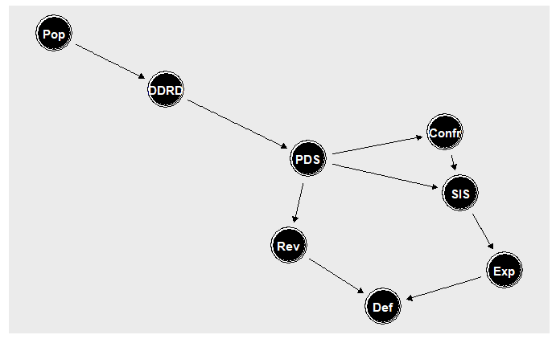

```r
dagx <- dagify(DDRD ~ Pop,
              Def ~ Exp,
              Def ~ Rev,
               Exp ~ SIS,
               Confr ~ PDS,
              SIS ~ Confr,
               SIS ~ PDS,
               PDS ~ DDRD,
              Rev ~ PDS)

ggdag(dagx)
```

*where Pop = Population of the municipality, DDRD = Direct Democracy/Representative Democracy, PDS = Political Decision-System, SIS = Special Interest Spending, Confr = tendency for confrontation between neighbors, Rev = Revenue, Exp = Expenditure, Def = Deficit.*

This DAG is important as a premise for a RDD analysis as a key assumption is that the average potential outcomes around the cutoff are continuous,

i.e. $E(Y_i(d)|X_i = x)$ is continuous in $x$ around $X_i = c$ for $d = 0,1$ *where Y is the potential outcome, i is the municipality, d is the treatment variable (population) and $X_i$ is the forcing variable which wholly deterministically alters the treatment at the cutpoint $c$*. (Referred from Presentation 7, Mark Kayser, 2019)

If this continuity assumption is assumed, then we can estimate the local average treatment effect at the threshold: LATE = $E(Y_i(1)-Y_i(0)|X_i=c, )$, whereby elements are randomly selected into treatment at the threshold $c$.

Assuming the DAG is causally and factually correct, then population as a running variable is exogenous to the causal effect of the democratic system (treatment variable) on revenues, expenditures and deficits. The model then requires no conditioning on any covariates for there are no back door paths, observable and unobservable, assuming this DAG encompasses all causal effects.

However, this assumption does not hold if there is selection bias, given $x$ at the cutoff $c$. For example, if grants were provided at the cutoff population < 100, then it may cause deficits in direct democracy to be a lot higher than that of the representative democracy. Then, the ‘LATE’ is biased due to the provision of grants, which occur at the cutoff. A robustness check involves first checking if such a selection bias into treatment exists. One such test could be, such as that conducted by Sanz, is to see if there is a discontinuity in the covariate at the cutoff. Another test could be the covariate balance between the subsets before and after the cutoff. This test will be conducted in Chapter 7 of this paper.

# CHAPTER THREE: Data Preparation and Summary Statistics

## 3.1, 3.2 Data Preparation and Analysis

Firstly, data has to be prepared for further analysis. I took the most relevant information, especially those that will be used for descriptive statistics (Table 1) and the regression models later on. The years relevant to the analysis are those between 1988 and 2011 (inclusive).

```r
########### 3.1 Loading Data ###########
## Main Data
df<-read.dta("sanz_psrm.dta")
#str(data)
df_t <- as_tibble(df)

## Spain GDP Deflator from World Bank
#spain_gdpdeflator <- t(read.csv("spain_gdpdeflator.csv", stringsAsFactors = FALSE))
#col.names(spain_gdpdeflator) <- "GDP Deflator"
#gdpdef_t <- spain_gdpdeflator
#str(gdpdef_t)
#year = seq(1961,2019, by = 1)
#year_t<- year
#gdpdef_t
#str(year_t)
#bind_cols(gdpdef_t,year)
```

```r
########### 3.2 Extracting Relevant Covariates ###########

library(psych, quietly = TRUE, warn.conflicts = FALSE)
# Quick look at the data
#glimpse(df_t)

#df.continuous <- data_tibble %>% select_if(is.numeric)

#glimpse(df.continuous)
#Removing missing data
#df.continuous<-na.omit(df.continuous)


# Extracting data between (including) 1988 and 2011.
df.selected <- df_t %>%
  select("expenditures_c","revenues_c","deficit_c","g_p_votes_pp","g_p_votes_psoe","g_p_votes_iu","g_p_diff","g_p_votes_winner","g_p_turnout","age_avg","sh_young","sh_adult","sh_old","sh_foreign","sh_eu", "population","unemployment_rate","year","dd","l_log_revenues_c","l_log_expenditures_c","l_deficit_c","id","log_revenues_c","log_expenditures_c") %>%
  filter(year>=1988 & year<=2011)

# Making sure that deficit_c has no NAs
# Function taken from: https://stackoverflow.com/questions/11254524/omit-rows-containing-specific# -column-of-na

completeFun <- function(data, desiredCols) {
  completeVec <- complete.cases(data[, desiredCols])
  return(data[completeVec, ])
}
df.selected<-completeFun(df.selected,c("expenditures_c"))
```

## 3.3 Table 1 - Summary Statistics

Here, a summary of the relevant statistics (mean, standard deviation, 1st, 50th and 99th percentile and total count) was taken. This is a replication of the statistics as laid out in Table 1.

```r
######################## REPLICATING TABLE 1 ######################################
########### 3.3 Table 1 - Summary statistics ###########
# I used describe to calculate the 1st, 50th and 99th percentile.
summaryA<-df.selected %>%
  select(-one_of("dd","l_log_revenues_c","l_log_expenditures_c","l_deficit_c", "id", "year", "log_revenues_c", "log_expenditures_c")) %>%
  describe(check = TRUE, fast = TRUE, quant = c(0.01,0.5,0.99),na.rm=TRUE)

summaryA <- summaryA %>%
  select(mean, sd, Q0.01, Q0.5, Q0.99, n, min,max,range,se) %>%
  rename(p1 = Q0.01,
         p50 = Q0.5,
         p99 = Q0.99,
         count = n)
# Renaming row names to relevant names
row.names(summaryA)<- c("Expenditures (Euro per cap)",
         "Revenues (Euro per cap)",
         "Deficit (Euro per cap)",
         "PP Vote Sh (%)",
         "PSOE Vote Sh (%)",
         "IU Vote Sh (%)",
         "Votes Difference (%)",
         "Votes Winner (%)",
         "Turnout (%)",
         "Mean Age (years)",
         "Young (%)",
         "Middle-Aged (%)",
         "Old (%)",
         "Immigrants (%)",
         "EU Immigrants (%)",
         "Population (inhabitants)",
         "Unemployment (%)")

#summaryA
# Creating a nice table with kable
kable(summaryA, digits = 2) %>%
 kable_styling(bootstrap_options = c("striped","scale_down"), full_width = FALSE, position = "left")
```

|  | mean | sd | p1 | p50 | p99 | count | min | max | range | se |
| --- | --- | --- | --- | --- | --- | --- | --- | --- | --- | --- |
| Expenditures (Euro per cap) | 671.04 | 1321.93 | 74.51 | 460.11 | 3523.45 | 42162 | -3360.44 | 96404.50 | 99764.94 | 6.44 |
| Revenues (Euro per cap) | 647.27 | 1290.30 | 87.88 | 449.30 | 3374.89 | 42162 | 0.66 | 96404.50 | 96403.84 | 6.28 |
| Deficit (Euro per cap) | 23.77 | 270.76 | -272.06 | 0.00 | 874.82 | 42162 | -12443.64 | 18583.00 | 31026.64 | 1.32 |
| PP Vote Sh (%) | 51.59 | 21.10 | 2.06 | 54.13 | 92.16 | 42056 | 0.00 | 100.00 | 100.00 | 0.10 |
| PSOE Vote Sh (%) | 30.58 | 15.50 | 0.00 | 29.66 | 69.40 | 42056 | 0.00 | 100.00 | 100.00 | 0.08 |
| IU Vote Sh (%) | 3.20 | 3.72 | 0.00 | 2.17 | 17.07 | 35095 | 0.00 | 54.29 | 54.29 | 0.02 |
| Votes Difference (%) | 31.00 | 21.76 | 0.00 | 27.45 | 87.50 | 42056 | 0.00 | 100.00 | 100.00 | 0.11 |
| Votes Winner (%) | 59.34 | 13.17 | 32.73 | 57.89 | 92.31 | 42056 | 24.37 | 100.00 | 75.63 | 0.06 |
| Turnout (%) | 78.32 | 8.84 | 52.94 | 79.29 | 95.45 | 42056 | 2.11 | 100.00 | 97.89 | 0.04 |
| Mean Age (years) | 53.05 | 6.06 | 39.34 | 53.04 | 67.70 | 27582 | 28.06 | 80.79 | 52.73 | 0.04 |
| Young (%) | 9.23 | 5.54 | 0.00 | 8.89 | 23.44 | 27582 | 0.00 | 42.86 | 42.86 | 0.03 |
| Middle-Aged (%) | 53.43 | 9.22 | 29.17 | 53.64 | 74.58 | 27582 | 0.00 | 100.00 | 100.00 | 0.06 |
| Old (%) | 37.34 | 11.64 | 12.87 | 37.02 | 67.87 | 27582 | 0.00 | 100.00 | 100.00 | 0.07 |
| Immigrants (%) | 2.57 | 4.80 | 0.00 | 0.53 | 22.43 | 27569 | 0.00 | 65.64 | 65.64 | 0.03 |
| EU Immigrants (%) | 45.40 | 42.12 | 0.00 | 41.67 | 100.00 | 14338 | 0.00 | 100.00 | 100.00 | 0.35 |
| Population (inhabitants) | 130.90 | 62.39 | 19.00 | 128.00 | 247.00 | 42162 | 4.00 | 250.00 | 246.00 | 0.30 |
| Unemployment (%) | 2.15 | 2.18 | 0.00 | 1.69 | 9.40 | 32489 | 0.00 | 88.89 | 88.89 | 0.01 |

```r
# Here, DD = 1, RD = 0
df.selected<- df.selected %>%
  mutate(dd_bi = ifelse(dd == "DD", 1,0))
```

In addition to Table 1, I created a covariance table to test the covariate balance. Although technically I ought to subset the dataset based on the bandwidth used (since we aggregate the outcomes within the bandwidth), I first used the entire dataset for an initial check.

```r
########### 3.3b Covariate Balance Table ###########
# Preparation for covariate balance
summaryB <- df.selected %>%
  group_by(dd)%>%
  select(-one_of("dd","l_log_revenues_c","l_log_expenditures_c","l_deficit_c", "id", "year", "log_revenues_c", "log_expenditures_c"),"dd_bi")%>%
  summarise_all(funs(mean(., na.rm = T)))
colnames(summaryB)<-c("Democracy System","Expenditures (Euro per cap)",
         "Revenues (Euro per cap)",
         "Deficit (Euro per cap)",
         "PP Vote Sh (%)",
         "PSOE Vote Sh (%)",
         "IU Vote Sh (%)",
         "Votes Difference (%)",
         "Votes Winner (%)",
         "Turnout (%)",
         "Mean Age (years)",
         "Young (%)",
         "Middle-Aged (%)",
         "Old (%)",
         "Immigrants (%)",
         "EU Immigrants (%)",
         "Population (inhabitants)",
         "Unemployment (%)")
kable(summaryB, digits = 3) %>%
 kable_styling(bootstrap_options = c("striped","scale_down"), full_width = F, position = "left")%>%
    scroll_box(width = "900px",height = "200px")
```

| Democracy System | Expenditures (Euro per cap) | Revenues (Euro per cap) | Deficit (Euro per cap) | PP Vote Sh (%) | PSOE Vote Sh (%) | IU Vote Sh (%) | Votes Difference (%) | Votes Winner (%) | Turnout (%) | Mean Age (years) | Young (%) | Middle-Aged (%) | Old (%) | Immigrants (%) | EU Immigrants (%) | Population (inhabitants) | Unemployment (%) | NA |
| --- | --- | --- | --- | --- | --- | --- | --- | --- | --- | --- | --- | --- | --- | --- | --- | --- | --- | --- |
| RD | 588.104 | 563.891 | 24.213 | 49.128 | 31.374 | 3.161 | 28.102 | 57.540 | 78.309 | 51.810 | 10.520 | 53.827 | 35.653 | 2.800 | 45.679 | 166.151 | 2.381 | 0 |
| DD | 836.339 | 813.456 | 22.883 | 56.520 | 28.983 | 3.291 | 36.806 | 62.935 | 78.338 | 55.386 | 6.794 | 52.679 | 40.527 | 2.138 | 44.475 | 60.648 | 1.706 | 1 |

## 3.4 Figure 2 - Histogram of Population Sizes

A histogram of the municipality-year observations with bins of 5-inhabitants was replicated as Figure 2 in the paper. It is observed that there are slight observations between the observations of population that is obtained in the paper and the one produced here. However, the overall trend seems consistent.

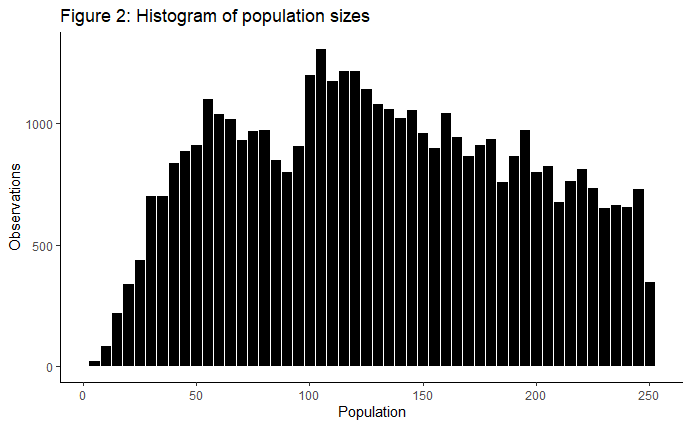

```r
######################## REPLICATING FIGURE 2 ######################################

########### 3.4: Figure 2 - Histogram ###########

# Histogram of population sizes with each observtion being a municipality-year. I made sure that the bin size is 5 as in the paper.
#windowsFonts(Times=windowsFont("Times New Roman"))
ggplot(df.selected, aes(x=population)) +
  geom_histogram(binwidth = 5,color = "white", fill = "black", position = "dodge")+
  ggtitle("Figure 2: Histogram of population sizes")+
  xlab("Population")+
  ylab("Observations")+
#  theme(text=element_text(family = "Times",face = "bold"))
  theme_classic()
```

# CHAPTER FOUR: Main Results - The Effect of Direct Democracy on Deficit

To begin the analysis, I chose to inspect the deficit first since the regressions with regards to the deficit were the most ambigious and non-significant regression discontinuity. The next three chapters will analyze each of the economic indicators as follows:

**Chapter Four: Effect of Direct Democracy on Deficit**

**Chapter Five: Effect of Direct Democracy on Revenues**

**Chapter Six: Effect of Direct Democracy on Expenditures**

*Note all effects on deficit are in Euros per capita, whilst that of revenues and expenditures are in the logarithm of Euros per capita, except where specified*

```r
cutoff <- 99.5 # Cut off used by Sanz to make sure that the cutoff is clear.

df.discon<-df.selected %>%
  mutate(pop_run = population - cutoff,
         deficit_c_dem = deficit_c,
         log_exp_dem   = log_expenditures_c,
         log_rev_dem   = log_revenues_c)
```

## 4.1 Effect of Direct Democracy on Deficits

Firstly, we inspect the running variable (population’s effect on the treatment variable (DD/RD). In the figure below, we see that the effect of the running variable results in a sharp RD at the cutoff (population = 100).

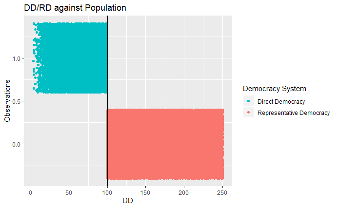

```r
########### 4.1 Visual Inspection ###########
# Inspecting if the running variable effect on the endogenous treatment variable results in a sharp or fuzzy RDD
df.discon %>%
  ggplot(aes(x = population, y = dd_bi,group = as.factor(dd), color = as.factor(dd)))+
  geom_point(position = "jitter") +
  geom_vline(xintercept = 100)+
  ggtitle("DD/RD against Population")+
  xlab("DD")+
  ylab("Observations")+
  scale_colour_discrete(name="Democracy System",
                         breaks=c("DD","RD"),
                         labels=c("Direct Democracy","Representative Democracy"))
```

Furthermore, we see no clear effect on the outcome variable (deficit) at the cutoff.

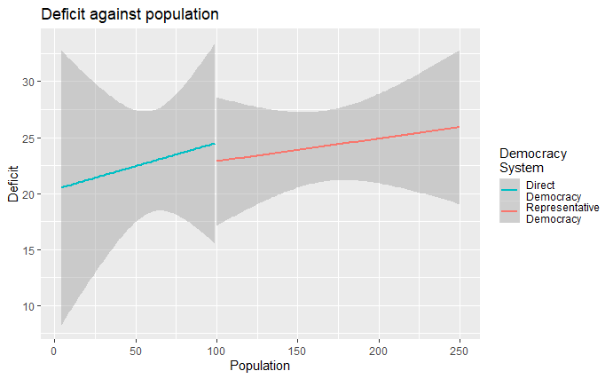

```r
# Looking at deficit at the cutoff
bw <-27
df.discon %>%
#   filter(pop_run > 0 - bw & pop_run < 0 + bw) %>%
 ggplot(aes(x = population, y = deficit_c_dem, group = as.factor(dd), color = as.factor(dd)))+
#  stat_summary(fun.y = "mean")+
#  stat_summary_bin(binwidth = 4)+
  stat_smooth(method=lm)+
  ggtitle("Deficit against population")+
  xlab("Population")+
  ylab("Deficit")+
  scale_colour_discrete(name="Democracy\nSystem",
                         breaks=c("DD","RD"),
                         labels=c("Direct\nDemocracy","Representative\nDemocracy"))
```

## 4.2, 4.3 Using *RDestimate* and *IKbandwidth*

The author here uses a fixed-effect regression discontinuity design, using both municipality and time fixed effects. To attempt to replicate the results found in the paper, I first use *RDestimate* and then *IKbandwidth* as well as a combination of the two. Both show different results than what was reported within the paper. An intriguing note is that the author used 0.5x and 1.5x (rather than 0.5x and 2.0x) the optimal BW to show robustness, perhaps to show more convincing regression estimates.

In these sections, I used RD estimate to estimate the results using the ‘optimal bandwidth’ from the paper. Thereafter, I manually calculated the IK bandwidth using *IKbandwidth* and plotted the results when the BW was 1x, 1.5x and 0.5x the optimal bandwidth. One major observation of the graphs is that there is no clear discontinuity at the cutoff. In fact, a non-linear (or even linear) fit may be appropriate. (This fact is further corroborated by the non-statistically significant results I replicated in the section below)

Unfortunately, the estimates of both the casual effect (even with the paper’s bandwidths) and the bandwidths calculated by these methods differ from the results in the paper. As such, in the following sections, I use other methods to derive the correct replicated results.

```r
########### 4.2 Using RD Estimate ###########

def_m<- RDestimate(deficit_c_dem~pop_run, data = df.discon, kernel = "rectangular",cutpoint = 0,bw = 98)
# bw = for bandwidth; using the data from the paper
summary(def_m)
```

```
Call:
RDestimate(formula = deficit_c_dem ~ pop_run, data = df.discon,
    cutpoint = 0, bw = 98, kernel = "rectangular")

Type:
sharp

Estimates:
           Bandwidth  Observations  Estimate  Std. Error  z value  Pr(>|z|)
LATE        98        34466          1.677    5.956        0.2816  0.7783
Half-BW     49        20694          1.722    7.502        0.2296  0.8184
Double-BW  196        42162         -1.645    5.759       -0.2856  0.7752
---
Signif. codes:  0 '***' 0.001 '**' 0.01 '*' 0.05 '.' 0.1 ' ' 1

F-statistics:
           F       Num. DoF  Denom. DoF  p
LATE       0.4177  3         34462       0.5193
Half-BW    0.6280  3         20690       0.8064
Double-BW  0.2301  3         42158       0.2491
```

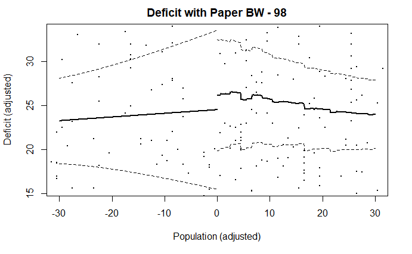

```r
RDplot(def_m, range = c(-30,30), main="Deficit with Paper BW - 98", xlab="Population (adjusted)",ylab="Deficit (adjusted)")
```

```r
########### 4.3 Manually calculating the IK Bandwidth and modelling for the 1.5-BW and Half-BW ###########

def_ik<- IKbandwidth(Y=df.discon$deficit_c_dem, X=df.discon$pop_run,cutpoint = 0,kernel = "rectangular")

def_ikm<- RDestimate(deficit_c_dem~pop_run, data = df.discon, kernel = "rectangular",cutpoint = 0,bw = def_ik)
summary(def_ikm)
```

```
Call:
RDestimate(formula = deficit_c_dem ~ pop_run, data = df.discon,
    cutpoint = 0, bw = def_ik, kernel = "rectangular")

Type:
sharp

Estimates:
           Bandwidth  Observations  Estimate  Std. Error  z value  Pr(>|z|)
LATE       20.88       8972         -4.758    12.109      -0.3930  0.6944
Half-BW    10.44       4310          6.628    16.563       0.4002  0.6890
Double-BW  41.77      17729          1.330     8.144       0.1634  0.8702
---
Signif. codes:  0 '***' 0.001 '**' 0.01 '*' 0.05 '.' 0.1 ' ' 1

F-statistics:
           F       Num. DoF  Denom. DoF  p
LATE       0.6142  3          8968       0.7886
Half-BW    0.2082  3          4306       0.2185
Double-BW  0.2074  3         17725       0.2173
```

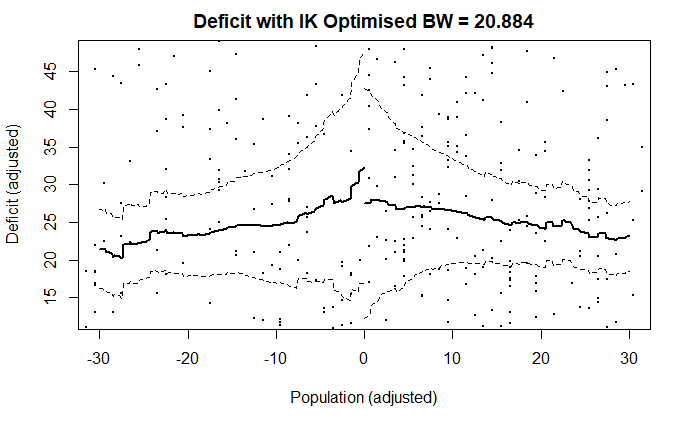

```r
RDplot(def_ikm, range = c(-30,30), main="Deficit with IK Optimised BW = 20.884", xlab="Population (adjusted)",ylab="Deficit (adjusted)")
```

```r
def_ikm_15<- RDestimate(deficit_c_dem~pop_run, data = df.discon, kernel = "rectangular",cutpoint = 0,bw = def_ik*1.5)
summary(def_ikm_15)
```

```
Call:
RDestimate(formula = deficit_c_dem ~ pop_run, data = df.discon,
    cutpoint = 0, bw = def_ik * 1.5, kernel = "rectangular")

Type:
sharp

Estimates:
           Bandwidth  Observations  Estimate  Std. Error  z value  Pr(>|z|)
LATE       31.33      13192          3.392     9.776       0.3470  0.7286
Half-BW    15.66       6809         -7.682    13.575      -0.5659  0.5715
Double-BW  62.65      25788          4.078     6.758       0.6035  0.5462
---
Signif. codes:  0 '***' 0.001 '**' 0.01 '*' 0.05 '.' 0.1 ' ' 1

F-statistics:
           F       Num. DoF  Denom. DoF  p
LATE       0.2206  3         13188       0.2356
Half-BW    0.7095  3          6805       0.9076
Double-BW  0.2948  3         25784       0.3417
```

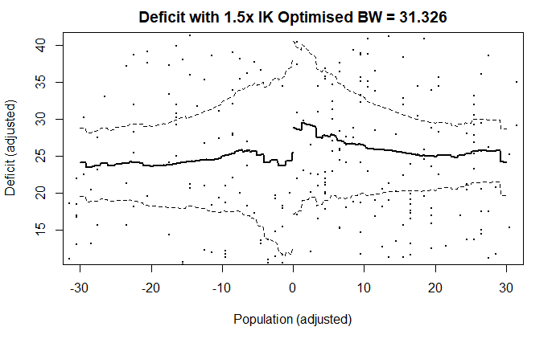

```r
RDplot(def_ikm_15, range = c(-30,30), main="Deficit with 1.5x IK Optimised BW = 31.326", xlab="Population (adjusted)",ylab="Deficit (adjusted)")
```

```r
def_ikm_05<- RDestimate(deficit_c_dem~pop_run, data = df.discon, kernel = "rectangular",cutpoint = 0,bw = def_ik*0.5)
summary(def_ikm_05)
```

```
Call:
RDestimate(formula = deficit_c_dem ~ pop_run, data = df.discon,
    cutpoint = 0, bw = def_ik * 0.5, kernel = "rectangular")

Type:
sharp

Estimates:
           Bandwidth  Observations  Estimate  Std. Error  z value  Pr(>|z|)
LATE       10.442     4310           6.628    16.56        0.4002  0.6890
Half-BW     5.221     2257          11.634    18.43        0.6312  0.5279
Double-BW  20.884     8972          -4.758    12.11       -0.3930  0.6944
---
Signif. codes:  0 '***' 0.001 '**' 0.01 '*' 0.05 '.' 0.1 ' ' 1

F-statistics:
           F       Num. DoF  Denom. DoF  p
LATE       0.2082  3         4306        0.2185
Half-BW    0.4336  3         2253        0.5421
Double-BW  0.6142  3         8968        0.7886
```

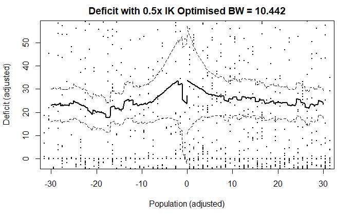

```r
RDplot(def_ikm_05, range = c(-30,30), main="Deficit with 0.5x IK Optimised BW = 10.442", xlab="Population (adjusted)",ylab="Deficit (adjusted)")
```

## 4.4 Using *rdbwselect_2014* and *RDestimate*

Finally, I used *rdbwselect_2014* to calculate the IK derived bandwidth estimates. This allowed me to obtain the correct bandwidths. For the models in 4.4, I used *RDestimate*, which provided regression estimates without any fixed effects. Furthermore, I used a uniform/rectangular kernel to match that used in the paper. This means that each observation of muncipality-year is weighted equally. The bandwidth selection used was the Imbens-Kalyanaram method with the outcome variable (deficit/ logarithm of expenditure or revenue) as the dependent variable and the population as the running variable.

```r
########### 4.4 Trying RD Robust Instead ###########
# This verifies the results of the paper; therefore, he used this function to calculate the estimates.
def_rddrobust_bw <- rdbwselect_2014(y=df.discon$deficit_c_dem, x=df.discon$pop_run, c = 0 , kernel = "uni", bwselect = "IK")
bw<-def_rddrobust_bw$bws[1]
bw_def<-bw
def_robustm<- RDestimate(deficit_c_dem~pop_run, data = df.discon, kernel = "rectangular",cutpoint = 0,bw = def_rddrobust_bw$bws[1])
summary(def_robustm)
```

```
Call:
RDestimate(formula = deficit_c_dem ~ pop_run, data = df.discon,
    cutpoint = 0, bw = def_rddrobust_bw$bws[1], kernel = "rectangular")

Type:
sharp

Estimates:
           Bandwidth  Observations  Estimate  Std. Error  z value  Pr(>|z|)
LATE        98.6      34617          1.851    5.945        0.3114  0.7555
Half-BW     49.3      20694          1.722    7.502        0.2296  0.8184
Double-BW  197.2      42162         -1.645    5.759       -0.2856  0.7752
---
Signif. codes:  0 '***' 0.001 '**' 0.01 '*' 0.05 '.' 0.1 ' ' 1

F-statistics:
           F       Num. DoF  Denom. DoF  p
LATE       0.4925  3         34613       0.6251
Half-BW    0.6280  3         20690       0.8064
Double-BW  0.2301  3         42158       0.2491
```

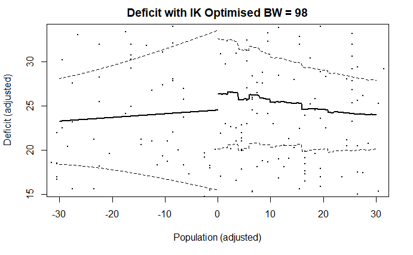

```r
RDplot(def_robustm, range = c(-30,30), main="Deficit with IK Optimised BW = 98", xlab="Population (adjusted)",ylab="Deficit (adjusted)")
```

```r
def_robust_15<- RDestimate(deficit_c_dem~pop_run, data = df.discon, kernel = "rectangular",cutpoint = 0,bw = def_rddrobust_bw$bws[1]*1.5)
summary(def_robust_15)
```

```
Call:
RDestimate(formula = deficit_c_dem ~ pop_run, data = df.discon,
    cutpoint = 0, bw = def_rddrobust_bw$bws[1] * 1.5, kernel = "rectangular")

Type:
sharp

Estimates:
           Bandwidth  Observations  Estimate  Std. Error  z value   Pr(>|z|)
LATE       147.91     41811         -0.2661   5.618       -0.04736  0.9622
Half-BW     73.95     29277          2.0668   6.085        0.33965  0.7341
Double-BW  295.81     42162         -1.6450   5.759       -0.28564  0.7752
---
Signif. codes:  0 '***' 0.001 '**' 0.01 '*' 0.05 '.' 0.1 ' ' 1

F-statistics:
           F       Num. DoF  Denom. DoF  p
LATE       0.1129  3         41807       0.09486
Half-BW    0.7995  3         29273       0.98782
Double-BW  0.2301  3         42158       0.24906
```

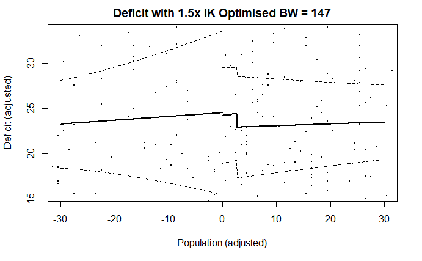

```r
RDplot(def_robust_15, range = c(-30,30), main="Deficit with 1.5x IK Optimised BW = 147", xlab="Population (adjusted)",ylab="Deficit (adjusted)")
```

```r
def_robust_05<- RDestimate(deficit_c_dem~pop_run, data = df.discon, kernel = "rectangular",cutpoint = 0,bw = def_rddrobust_bw$bws[1]*0.5)
summary(def_robust_05)
```

```
Call:
RDestimate(formula = deficit_c_dem ~ pop_run, data = df.discon,
    cutpoint = 0, bw = def_rddrobust_bw$bws[1] * 0.5, kernel = "rectangular")

Type:
sharp

Estimates:
           Bandwidth  Observations  Estimate  Std. Error  z value  Pr(>|z|)
LATE       49.30      20694          1.722     7.502       0.2296  0.8184
Half-BW    24.65      10662         -4.415    10.975      -0.4023  0.6875
Double-BW  98.60      34617          1.851     5.945       0.3114  0.7555
---
Signif. codes:  0 '***' 0.001 '**' 0.01 '*' 0.05 '.' 0.1 ' ' 1

F-statistics:
           F       Num. DoF  Denom. DoF  p
LATE       0.6280  3         20690       0.8064
Half-BW    0.7302  3         10658       0.9323
Double-BW  0.4925  3         34613       0.6251
```

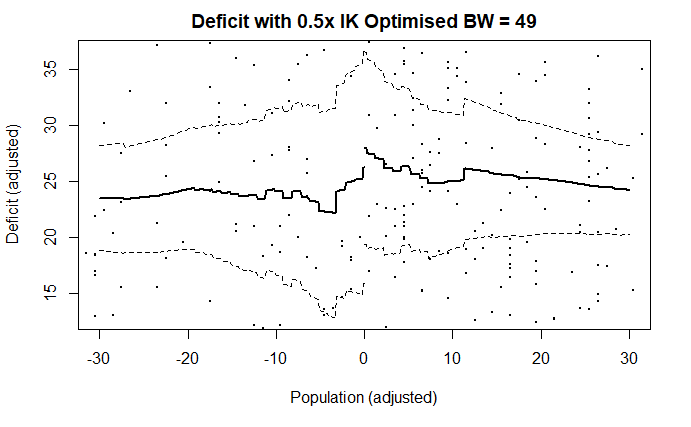

```r
RDplot(def_robust_05, range = c(-30,30), main="Deficit with 0.5x IK Optimised BW = 49", xlab="Population (adjusted)",ylab="Deficit (adjusted)")
```

```r
NA
NA
```

## 4.5 Using *rdbwselect_2014* and *plm*

Finally, I used the bandwidth obtained from *rdbwselect_2014* and subsetted the data to within the bandwidth. Thereafter, I used *plm* to apply a fixed-effects linear regression to the dataset. This provides me with the correct regression estimates as stated in Sanz, 2018. Here, it is noteworthy that the fixed effects model is a two-way fixed effects model, accounting for both unit (municipality) and time (year) fixed effects. Running a two-way fixed effects model is equivalent to creating dummy variables for both the municipalities and the years.

In addition, I made use of the *coeftest* function in conjunction with *vcovHC* to cluster the standard errors around the municipalities. This caused the standard errors to be closer to that reported in the paper. However, there are still slight discrepancies between the standard errors found here and that in the paper, which could result from the differences in calculating these errors by R and Stata. Furthermore, I declare that here I am unsure if my current method involves clustering on both the running variable and the municipalities or just the municipalities. However, I assume the former occurs as the standard errors have to be clustered on the independent variable (the running variable or population, in this case).

It is noteworthy that the number of observations differs slightly (34,617 in my results as compared to 34,570 in Sanz’s results). However, the estimates are accurate.

```r
########## 4.5 Using PLM to Estimate the Effect ##########

bw_def3 <- bw_def*c(1,1.5,0.5) # all the relevant bandwidths

######################### NORMAL BANDWIDTH ########################
## Subsetting the data to within the bandwidth
bw <- bw_def3[1] # Selecting the right bandwidth
df.plm<-df.discon %>%
  filter(pop_run > 0 - bw & pop_run < 0 + bw) %>%
  mutate(dd_pop_run = dd_bi*pop_run)

#str(df.plm)
## Running the linear PLM Model
def_plm <- plm(deficit_c_dem~pop_run+dd_bi+dd_pop_run, data = df.plm,index = c("id","year"), model = "within", effect = "twoways")
 summary(def_plm)
```

```
Twoways effects Within Model

Call:
plm(formula = deficit_c_dem ~ pop_run + dd_bi + dd_pop_run, data = df.plm,
    effect = "twoways", model = "within", index = c("id",
        "year"))

Unbalanced Panel: n = 2286, T = 1-24, N = 34617

Residuals:
       Min.     1st Qu.      Median     3rd Qu.        Max.
-10440.5837    -38.2539     -6.9417     14.8811   7740.4313

Coefficients:
            Estimate Std. Error t-value Pr(>|t|)
pop_run     0.029562   0.120204  0.2459 0.805737
dd_bi      -7.877209   7.489802 -1.0517 0.292934
dd_pop_run -0.669150   0.246796 -2.7114 0.006704 **
---
Signif. codes:  0 ‘***’ 0.001 ‘**’ 0.01 ‘*’ 0.05 ‘.’ 0.1 ‘ ’ 1

Total Sum of Squares:    1952700000
Residual Sum of Squares: 1952200000
R-Squared:      0.0002459
Adj. R-Squared: -0.071273
F-statistic: 2.64853 on 3 and 32305 DF, p-value: 0.047168
```

```r
## Clustering the standard errors around
 #arellano & HC1 work the best
def_plm_c<-coeftest(def_plm,vcov=vcovHC(def_plm, method = "arellano",type="HC1", cluster = "group"))

# Standard Linear Model gives the same result
#  def_lm <- lm(deficit_c_dem~pop_run+dd_bi+dd_pop_run + factor(year)+factor(id), data = df.plm)
#  summary(def_lm)
#  vcov_both <- cluster.vcov(def_lm, cbind(df.plm$id, df.plm$pop_run))
#  coeftest(def_lm, vcov_both)  # std error produced= 9.8949

## Running the Cubic PLM Model
def_plm_cubic <- plm(deficit_c_dem~pop_run+dd_bi+I(dd_bi*pop_run)+ + I(dd_bi*pop_run^2)+I(dd_bi*pop_run^3)+I(pop_run^2)+I(pop_run^3),
                     data = df.discon,index = c("id","year"), model = "within", effect = "twoways")
  summary(def_plm_cubic)
```

```
Twoways effects Within Model

Call:
plm(formula = deficit_c_dem ~ pop_run + dd_bi + I(dd_bi * pop_run) +
    +I(dd_bi * pop_run^2) + I(dd_bi * pop_run^3) + I(pop_run^2) +
    I(pop_run^3), data = df.discon, effect = "twoways",
    model = "within", index = c("id", "year"))

Unbalanced Panel: n = 2689, T = 1-24, N = 42162

Residuals:
       Min.     1st Qu.      Median     3rd Qu.        Max.
-11416.6887    -39.1662     -7.8133     14.7803  17199.1433

Coefficients:
                        Estimate  Std. Error t-value Pr(>|t|)
pop_run              -1.0133e-01  4.4255e-01 -0.2290   0.8189
dd_bi                 6.3229e+00  1.2020e+01  0.5260   0.5989
I(dd_bi * pop_run)    4.7491e-01  1.1955e+00  0.3972   0.6912
I(dd_bi * pop_run^2) -3.6472e-03  3.3524e-02 -0.1088   0.9134
I(dd_bi * pop_run^3) -3.3165e-04  2.7278e-04 -1.2158   0.2241
I(pop_run^2)          8.0374e-04  6.9078e-03  0.1164   0.9074
I(pop_run^3)          9.1819e-06  3.0936e-05  0.2968   0.7666

Total Sum of Squares:    2701700000
Residual Sum of Squares: 2698500000
R-Squared:      0.0012048
Adj. R-Squared: -0.067622
F-statistic: 6.79696 on 7 and 39443 DF, p-value: 4.3536e-08
```

```r
def_plm_cubic_c<-coeftest(def_plm_cubic,vcov=vcovHC(def_plm_cubic, method = "arellano",type="HC1", cluster = "group"))
######################### 1.5x BANDWIDTH ########################
## Subsetting the data to within the bandwidth
bw <- bw_def3[2] # Selecting the right bandwidth
df.plm15<-df.discon %>%
  filter(pop_run > 0 - bw & pop_run < 0 + bw) %>%
  mutate(dd_pop_run = dd_bi*pop_run)

#str(df.plm)
## Running the linear PLM Model
def_plm15 <- plm(deficit_c_dem~pop_run+dd_bi+dd_pop_run, data = df.plm15,index = c("id","year"), model = "within", effect = "twoways")
 summary(def_plm15)
```

```
Twoways effects Within Model

Call:
plm(formula = deficit_c_dem ~ pop_run + dd_bi + dd_pop_run, data = df.plm15,
    effect = "twoways", model = "within", index = c("id",
        "year"))

Unbalanced Panel: n = 2670, T = 1-24, N = 41811

Residuals:
       Min.     1st Qu.      Median     3rd Qu.        Max.
-11421.5841    -38.6972     -7.5991     14.9133  10742.0849

Coefficients:
            Estimate Std. Error t-value  Pr(>|t|)
pop_run     0.123620   0.086393  1.4309    0.1525
dd_bi      -5.951107   7.350068 -0.8097    0.4181
dd_pop_run -1.031279   0.234257 -4.4023 1.074e-05 ***
---
Signif. codes:  0 ‘***’ 0.001 ‘**’ 0.01 ‘*’ 0.05 ‘.’ 0.1 ‘ ’ 1

Total Sum of Squares:    2367900000
Residual Sum of Squares: 2366700000
R-Squared:      0.00051622
Adj. R-Squared: -0.068348
F-statistic: 6.73411 on 3 and 39115 DF, p-value: 0.00015448
```

```r
def_plm15_c<-coeftest(def_plm15,vcov=vcovHC(def_plm15, method = "arellano",type="HC1", cluster = "group"))

 ## Attempting to cluster all the SEs based on the municipalilty and the running variable
#coef_test(def_plm15, vcov = "CR1", cluster = "individual", test = "naive-t")
#coeftest(def_plm15, vcov.=function(x) #vcovDC(x, type="HC1", maxlag=4))
#  def_plm15$coefficients[["dd_bi"]]

# Tried to use clustering
#vcov_both <- cluster.vcov(def_plm15, cbind(df.plm15$id, df.plm15$pop_run))
#coeftest(m1, vcov_both)

######################### 0.5x BANDWIDTH ########################
## Subsetting the data to within the bandwidth
bw <- bw_def3[3] # Selecting the right bandwidth
df.plm05<-df.discon %>%
  filter(pop_run > 0 - bw & pop_run < 0 + bw) %>%
  mutate(dd_pop_run = dd_bi*pop_run)

#str(df.plm)

## Running the linear PLM Model
def_plm05 <- plm(deficit_c_dem~pop_run+dd_bi+dd_pop_run, data = df.plm05,index = c("id","year"), model = "within", effect = "twoways")
  summary(def_plm05)
```

```
Twoways effects Within Model

Call:
plm(formula = deficit_c_dem ~ pop_run + dd_bi + dd_pop_run, data = df.plm05,
    effect = "twoways", model = "within", index = c("id",
        "year"))

Unbalanced Panel: n = 1603, T = 1-24, N = 20694

Residuals:
      Min.    1st Qu.     Median    3rd Qu.       Max.
-6528.3149   -37.3343    -6.3369    15.3868  7498.4366

Coefficients:
           Estimate Std. Error t-value Pr(>|t|)
pop_run    -0.25960    0.24001 -1.0816  0.27944
dd_bi       0.24161    8.22325  0.0294  0.97656
dd_pop_run  0.64500    0.35286  1.8279  0.06758 .
---
Signif. codes:  0 ‘***’ 0.001 ‘**’ 0.01 ‘*’ 0.05 ‘.’ 0.1 ‘ ’ 1

Total Sum of Squares:    1060800000
Residual Sum of Squares: 1060600000
R-Squared:      0.00017773
Adj. R-Squared: -0.085199
F-statistic: 1.12969 on 3 and 19065 DF, p-value: 0.33547
```

```r
def_plm05_c<-coeftest(def_plm05,vcov=vcovHC(def_plm05, method = "arellano",type="HC1", cluster = "group"))

  ## Testing prediction models
  # Doesn't seem to work
#df.plm$test  <-predict(def_lm)
#ggplot(df.plm,aes(x = pop_run, y = test))+
#  geom_line()
#  geom_point(aes(x = pop_run,y = deficit_c_dem))
```

The table here presents the regression results with robust standard errors, summarizing the results of the four models run above:

1. Optimal bandwidth linear model
2. 1.5x Optimal bandwidth linear model
3. 0.5x Optimal bandwidth linear model
4. Cubic model (using no bandwidth, i.e. the entire dataset)

```r
stargazer(
          def_plm,def_plm15,def_plm05,def_plm_cubic,
          se = list(def_plm_c[,2],def_plm15_c[,2],def_plm05_c[,2],def_plm_cubic_c[,2]),
          type = "html",
          title = "Deficit PLM Results with Robust SE",
          dep.var.caption = "Deficit",
          dep.var.labels = "Difference in revenue and expenditure (\u20AC)",
          omit = c("year"),
          column.labels = c("Optimized BW","1.5 x BW", "0.5 x BW", "Cubic Model (Full Data)"),
          suppress.errors = TRUE,
          notes = "BW = 98, 1.5 x BW = 147, 0.5 x BW = 49",
          order = c(2,1,3),
          model.names = FALSE,
          covariate.labels = c("Direct democracy","Population","Direct democracy x Population"))
```

**Deficit PLM Results with Robust SE**

|  | Deficit |  |  |  |
| --- | --- | --- | --- | --- |
|  | Difference in revenue and expenditure (€) |  |  |  |
|  | Optimized BW | 1.5 x BW | 0.5 x BW | Cubic Model (Full Data) |
|  | (1) | (2) | (3) | (4) |
| Direct democracy | -7.877 | -5.951 | 0.242 | 6.323 |
|  | (8.160) | (8.536) | (9.425) | (15.391) |
| Population | 0.030 | 0.124 | -0.260 | -0.101 |
|  | (0.146) | (0.198) | (0.313) | (0.784) |
| Direct democracy x Population | -0.669* | -1.031** | 0.645 |  |
|  | (0.353) | (0.505) | (0.440) |  |
| I(dd_bi * pop_run) |  |  |  | 0.475 |
|  |  |  |  | (1.625) |
| I(dd_bi * pop_run2) |  |  |  | -0.004 |
|  |  |  |  | (0.048) |
| I(dd_bi * pop_run3) |  |  |  | -0.0003 |
|  |  |  |  | (0.0005) |
| I(pop_run2) |  |  |  | 0.001 |
|  |  |  |  | (0.014) |
| I(pop_run3) |  |  |  | 0.00001 |
|  |  |  |  | (0.0001) |
| Observations | 34,617 | 41,811 | 20,694 | 42,162 |
| R<sup>2</sup> | 0.0002 | 0.001 | 0.0002 | 0.001 |
| Adjusted R<sup>2</sup> | -0.071 | -0.068 | -0.085 | -0.068 |
| F Statistic | 2.649** (df = 3; 32305) | 6.734*** (df = 3; 39115) | 1.130 (df = 3; 19065) | 6.797*** (df = 7; 39443) |
| *Note:* | p<0.1; p<0.05; p<0.01 |  |  |  |
|  | BW = 98, 1.5 x BW = 147, 0.5 x BW = 49 |  |  |  |

## 4.6 Replicating Figure 3

Figure 3 was used as a graphical representation that incorporates the fixed effects of the model into the equation estimated in Table 2. As such, the author estimates:

$Outcome_{myt} = \alpha_{0m} + \gamma_y + \sum^{100 + OBW}_{100-OBW} \delta_jPopulation_{j,mt}$

I was unsure as to how this equation was actually derived. My first method, which seems not to work, is to take the fixed effects form the model and apply them directly to give me $\alpha_{0m}$ and $\gamma_y$. I run a linear regression with dummy variables for each population, thereby regressing to obtain $\delta_j$ which will be the coefficient of the respective dummy variables. Using these $\delta_j$ values and binning them into four population observations, I form the figure as seen below by plotting $\delta_j$ against the population variable.

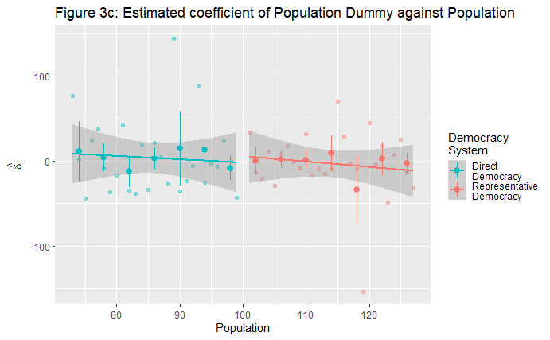

```r
########## 4.6 Replicating Figure 3 ##########
## Replicating for Figure 3

# Subsetting the data to the bandwidth of expenditures as done by the author.
bw <- 27
df.fig3.left<-df.discon %>%
    filter(pop_run > 0 - bw & pop_run < 0)
df.fig3.right<-df.discon %>%
    filter(pop_run > 0 & pop_run < 0 + bw)
#str(df.fig3.left)
def_plm2 <- plm(deficit_c_dem~pop_run+dd_bi+dd_pop_run+as.factor(year), data = df.plm,index = c("id"), model = "within")

#Taking the fixed effects of the years from the model
def_fix_year <- def_plm2$coefficients[4:length(def_plm2$coefficients)]
#def_fix_year

# Cretaing the Years. Note that the element number of this vector year is the same as the def_fix_year
Year<-1989:2011
#Year

#df_fe_year <- data.frame(year,def_fix_unit)

# Taking the fixed effects of the unit from the model
def_fix_unit <- fixef(def_plm2)
def_fix_unit_e<-summary(def_fix_unit)[,c("Estimate")]

# Extracting the IDs. Note that the element number of this vector ID is the same as the def_fix_unit
ID<-unique(strtoi(list.names(def_fix_unit)))


df_fe_year <- data.frame(Year,def_fix_year)
df_fe_unit <- data.frame(ID,def_fix_unit_e)

df.fig3.left$fe_unit<-df_fe_unit$def_fix_unit_e[match(df.fig3.left$id,df_fe_unit$ID)]
#df.fig3.left$fe_unit
df.fig3.left$fe_year<-df_fe_year$def_fix_year[match(df.fig3.left$year,df_fe_year$Year)]
#df.fig3.left$fe_year

df.fig3.left<-df.fig3.left %>%
  na.omit(c(fe_year,fe_unit))%>%
  mutate(outcome_mutate=deficit_c_dem-fe_year-fe_unit)

def_left<-lm(outcome_mutate~as.factor(pop_run)-1,data=df.fig3.left)

def_coef_left<-def_left$coefficients
def_coef_left<-unname(def_coef_left,force=TRUE)
def_pop_left<-73:99
def_id_left<-rep(1,length(def_pop_left))
def_left_t<-data.frame(def_pop_left,def_coef_left,def_id_left)
def_left_t<-setNames(def_left_t,c("pop","coef","id"))

df.fig3.right$fe_unit<-df_fe_unit$def_fix_unit_e[match(df.fig3.right$id,df_fe_unit$ID)]
#df.fig3.right$fe_unit
df.fig3.right$fe_year<-df_fe_year$def_fix_year[match(df.fig3.right$year,df_fe_year$Year)]
#df.fig3.right$fe_year

df.fig3.right<-df.fig3.right %>%
  na.omit(c(fe_year,fe_unit))%>%
  mutate(outcome_mutate=deficit_c_dem-fe_year-fe_unit)

def_right<-lm(outcome_mutate~as.factor(pop_run)-1,data=df.fig3.right)
#length(def_right$coefficients)
def_coef_right<-def_right$coefficients
def_coef_right<-unname(def_coef_right,force=TRUE)
#def_coef_right
def_pop_right<-101:127
def_id_right<-rep(0,length(def_pop_right))
def_right_t<-data.frame(def_pop_right,def_coef_right,def_id_right)
def_right_t<-setNames(def_right_t,c("pop","coef","id"))

# Binding the two tibbles
def_rightleft<-rbind(def_right_t,def_left_t)
#Normalizing based upon the first bin of four observations (i.e. 101:104) to the right of the cutoff.
def_rightleft<-def_rightleft %>%
  mutate(coef=coef-mean(coef[1:3]))
#def_rightleft

ggplot(def_rightleft,aes(x=pop,y=coef,color = as.factor(id)))+
  geom_point(alpha = 0.4)+
  stat_smooth(method="lm")+
  stat_summary_bin(binwidth = 4)+
  ggtitle("Figure 3c: Estimated coefficient of Population Dummy against Population")+
  xlab("Population")+
  ylab(bquote(hat(delta[j])))+
  scale_colour_discrete(name="Democracy\nSystem",
                         breaks=c("1","0"),
                         labels=c("Direct\nDemocracy","Representative\nDemocracy"))
```

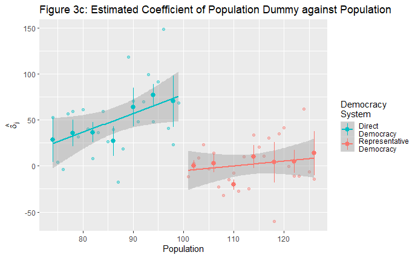

```r
# Running a linear regression on population with fixed effects of the municipality and the year.
def_left<-lm(deficit_c_dem~as.factor(id)+as.factor(year)+as.factor(population)-1,data=df.fig3.left)
#def_left$coefficients[661:686]
def_coef_left<-def_left$coefficients[675:700]
#def_coef_left
def_coef_left<-unname(def_coef_left,force=TRUE)
def_pop_left<-74:99
def_id_left<-rep(1,length(def_pop_left))
def_left_t<-data.frame(def_pop_left,def_coef_left,def_id_left)
def_left_t<-setNames(def_left_t,c("pop","coef","id"))

def_right<-lm(deficit_c_dem~as.factor(id)+as.factor(year)+as.factor(population),data=df.fig3.right)
#length(def_right$coefficients)
def_coef_right<-def_right$coefficients[903:928]
def_coef_right<-unname(def_coef_right,force=TRUE)
#def_coef_right
def_pop_right<-101:126
def_id_right<-rep(0,length(def_pop_right))
def_right_t<-data.frame(def_pop_right,def_coef_right,def_id_right)
def_right_t<-setNames(def_right_t,c("pop","coef","id"))

# Binding the two tibbles
def_rightleft<-rbind(def_right_t,def_left_t)
#Normalizing based upon the first bin of four observations (i.e. 101:104) to the right of the cutoff.
def_rightleft<-def_rightleft %>%
  mutate(coef=coef-mean(coef[1:3]))
#def_rightleft

ggplot(def_rightleft,aes(x=pop,y=coef,color = as.factor(id)))+
  geom_point(alpha = 0.4)+
  stat_smooth(method="lm")+
  stat_summary_bin(binwidth = 4)+
  ggtitle("Figure 3c: Estimated Coefficient of Population Dummy against Population")+
  xlab("Population")+
  ylab(bquote(hat(delta[j])))+
    scale_colour_discrete(name="Democracy\nSystem",
                         breaks=c("1","0"),
                         labels=c("Direct\nDemocracy","Representative\nDemocracy"))
```

# CHAPTER FIVE: Main Results - The Effect of Direct Democracy on Revenues

Having successfully replicated the main results of Table 2 for deficits, I will use the same sucessful methods for the logarithm of revenues (in this Chapter) and the logarithm of expenditures (in Chapter Six). This involves:

1. Calculating the accurate bandwidth using *rdbwselect_2014*
2. Subsetting the dataset based on the bandwidth
3. Running a two-way fixed effects model with robust standard errors using *plm* and *coeftest*
4. Calculating and ploting $\delta_j$ (different for each outcome variable) against the population variable

## 5.1 Visual Inspection

A rough visual inspection of the effect of direct democracy on the logarithm of revenue It is observed that there is a higher change in the outcome variable at the cutoff.

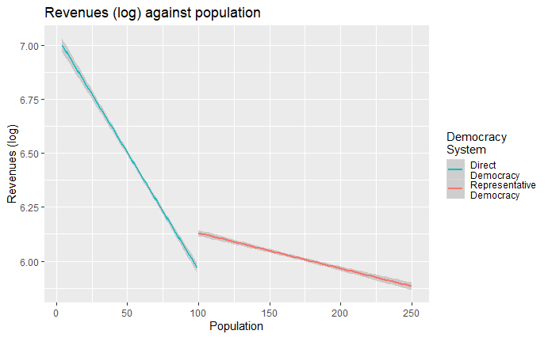

```r
########## 5.1 Visual Inspection ##########

df.discon %>%
 ggplot(aes(x = population, y = log_rev_dem, group = as.factor(dd), color = as.factor(dd)))+
  stat_smooth(method=lm)+
  ggtitle("Revenues (log) against population")+
  xlab("Population")+
  ylab("Revenues (log)")+
  scale_colour_discrete(name="Democracy\nSystem",
                         breaks=c("DD","RD"),
                         labels=c("Direct\nDemocracy","Representative\nDemocracy"))
```

## 5.2 Replicating Table 2 Results with PLM for Log Revenue

Avoiding all other methods, I will use *rdbwselect_2014* and *plm* directly.

```r
########## 5.2 Using PLM to Estimate the Effect ##########

rev_rddrobust_bw <- rdbwselect_2014(y=df.discon$log_revenues_c, x=df.discon$pop_run, c = 0 , kernel = "uni", bwselect = "IK")

# The Optimal Bandwidth, 1.5x and 0.5x
bw_rev3 <- rev_rddrobust_bw$bws[1]*(c(1,1.5,0.5))
#bw_rev3

######################### NORMAL BANDWIDTH ########################
## Subsetting the data to within the bandwidth
bw <- bw_rev3[1] # Selecting the right bandwidth
df.plm<-df.discon %>%
  filter(pop_run > 0 - bw & pop_run < 0 + bw) %>%
  mutate(dd_pop_run = dd_bi*pop_run)

## Running the linear PLM Model
rev_plm <- plm(log_rev_dem~pop_run+dd_bi+dd_pop_run, data = df.plm,index = c("id","year"), model = "within", effect = "twoways")
  summary(rev_plm)
```

```
Twoways effects Within Model

Call:
plm(formula = log_rev_dem ~ pop_run + dd_bi + dd_pop_run, data = df.plm,
    effect = "twoways", model = "within", index = c("id",
        "year"))

Unbalanced Panel: n = 1084, T = 1-24, N = 10662

Residuals:
     Min.   1st Qu.    Median   3rd Qu.      Max.
-1.880985 -0.181492 -0.017642  0.146828  3.639287

Coefficients:
              Estimate  Std. Error t-value  Pr(>|t|)
pop_run    -0.00565769  0.00086841 -6.5150 7.637e-11 ***
dd_bi      -0.05212404  0.01763285 -2.9561  0.003123 **
dd_pop_run -0.00343292  0.00130792 -2.6247  0.008686 **
---
Signif. codes:  0 ‘***’ 0.001 ‘**’ 0.01 ‘*’ 0.05 ‘.’ 0.1 ‘ ’ 1

Total Sum of Squares:    1308.9
Residual Sum of Squares: 1287.2
R-Squared:      0.01658
Adj. R-Squared: -0.097597
F-statistic: 53.6798 on 3 and 9552 DF, p-value: < 2.22e-16
```

```r
rev_plm_c<-coeftest(rev_plm,vcov=vcovHC(rev_plm, method = "arellano",type="HC1", cluster = "group"))

## Running the Cubic PLM Model
rev_plm_cubic <- plm(log_rev_dem~pop_run+dd_bi+I(dd_bi*pop_run)+ + I(dd_bi*pop_run^2)+I(dd_bi*pop_run^3)+I(pop_run^2)+I(pop_run^3),
                     data = df.discon,index = c("id","year"), model = "within", effect = "twoways")
  summary(rev_plm_cubic)
```

```
Twoways effects Within Model

Call:
plm(formula = log_rev_dem ~ pop_run + dd_bi + I(dd_bi * pop_run) +
    +I(dd_bi * pop_run^2) + I(dd_bi * pop_run^3) + I(pop_run^2) +
    I(pop_run^3), data = df.discon, effect = "twoways",
    model = "within", index = c("id", "year"))

Unbalanced Panel: n = 2689, T = 1-24, N = 42162

Residuals:
     Min.   1st Qu.    Median   3rd Qu.      Max.
-5.374240 -0.204604 -0.025874  0.166938  5.036122

Coefficients:
                        Estimate  Std. Error t-value  Pr(>|t|)
pop_run              -4.7584e-03  6.5808e-04 -7.2307 4.891e-13 ***
dd_bi                -7.2499e-02  1.7874e-02 -4.0561 4.999e-05 ***
I(dd_bi * pop_run)   -9.5706e-03  1.7778e-03 -5.3834 7.353e-08 ***
I(dd_bi * pop_run^2) -2.5536e-04  4.9851e-05 -5.1225 3.029e-07 ***
I(dd_bi * pop_run^3) -3.8841e-06  4.0563e-07 -9.5754 < 2.2e-16 ***
I(pop_run^2)         -4.6071e-07  1.0272e-05 -0.0449    0.9642
I(pop_run^3)          6.0697e-08  4.6004e-08  1.3194    0.1870
---
Signif. codes:  0 ‘***’ 0.001 ‘**’ 0.01 ‘*’ 0.05 ‘.’ 0.1 ‘ ’ 1

Total Sum of Squares:    6350.6
Residual Sum of Squares: 5967
R-Squared:      0.060392
Adj. R-Squared: -0.0043559
F-statistic: 362.164 on 7 and 39443 DF, p-value: < 2.22e-16
```

```r
rev_plm_cubic_c<-coeftest(rev_plm_cubic,vcov=vcovHC(rev_plm_cubic, method = "arellano",type="HC1", cluster = "group"))
######################### 1.5x BANDWIDTH ########################
## Subsetting the data to within the bandwidth
bw <- bw_rev3[2] # Selecting the right bandwidth
df.plm15<-df.discon %>%
  filter(pop_run > 0 - bw & pop_run < 0 + bw) %>%
  mutate(dd_pop_run = dd_bi*pop_run)

#str(df.plm)
## Running the linear PLM Model
rev_plm15 <- plm(log_rev_dem~pop_run+dd_bi+dd_pop_run, data = df.plm15,index = c("id","year"), model = "within", effect = "twoways")
 summary(rev_plm15)
```

```
Twoways effects Within Model

Call:
plm(formula = log_rev_dem ~ pop_run + dd_bi + dd_pop_run, data = df.plm15,
    effect = "twoways", model = "within", index = c("id",
        "year"))

Unbalanced Panel: n = 1383, T = 1-24, N = 16117

Residuals:
     Min.   1st Qu.    Median   3rd Qu.      Max.
-1.913421 -0.187272 -0.020189  0.153357  3.796184

Coefficients:
              Estimate  Std. Error t-value  Pr(>|t|)
pop_run    -0.00533295  0.00052432 -10.171 < 2.2e-16 ***
dd_bi      -0.06366847  0.01450639  -4.389 1.147e-05 ***
dd_pop_run -0.00482735  0.00076081  -6.345 2.289e-10 ***
---
Signif. codes:  0 ‘***’ 0.001 ‘**’ 0.01 ‘*’ 0.05 ‘.’ 0.1 ‘ ’ 1

Total Sum of Squares:    2096.9
Residual Sum of Squares: 2037
R-Squared:      0.02858
Adj. R-Squared: -0.064414
F-statistic: 144.242 on 3 and 14708 DF, p-value: < 2.22e-16
```

```r
 rev_plm15_c<-coeftest(rev_plm15,vcov=vcovHC(rev_plm15, method = "arellano",type="HC1", cluster = "group"))
######################### 0.5x BANDWIDTH ########################
## Subsetting the data to within the bandwidth
bw <- bw_rev3[3] # Selecting the right bandwidth
df.plm05<-df.discon %>%
  filter(pop_run > 0 - bw & pop_run < 0 + bw) %>%
  mutate(dd_pop_run = dd_bi*pop_run)

## Running the linear PLM Model
rev_plm05 <- plm(log_rev_dem~pop_run+dd_bi+dd_pop_run, data = df.plm05,index = c("id","year"), model = "within", effect = "twoways")
  summary(rev_plm05)
```

```
Twoways effects Within Model

Call:
plm(formula = log_rev_dem ~ pop_run + dd_bi + dd_pop_run, data = df.plm05,
    effect = "twoways", model = "within", index = c("id",
        "year"))

Unbalanced Panel: n = 765, T = 1-23, N = 5578

Residuals:
    Min.  1st Qu.   Median  3rd Qu.     Max.
-1.69413 -0.16825 -0.01527  0.13492  3.41735

Coefficients:
              Estimate  Std. Error t-value  Pr(>|t|)
pop_run    -0.01331816  0.00224745 -5.9259 3.324e-09 ***
dd_bi      -0.10819085  0.02599528 -4.1619 3.211e-05 ***
dd_pop_run -0.00096811  0.00351589 -0.2754    0.7831
---
Signif. codes:  0 ‘***’ 0.001 ‘**’ 0.01 ‘*’ 0.05 ‘.’ 0.1 ‘ ’ 1

Total Sum of Squares:    617.61
Residual Sum of Squares: 608.67
R-Squared:      0.014486
Adj. R-Squared: -0.14815
F-statistic: 23.454 on 3 and 4787 DF, p-value: 4.5797e-15
```

```r
rev_plm05_c<-coeftest(rev_plm05,vcov=vcovHC(rev_plm05, method = "arellano",type="HC1", cluster = "group"))
```

The table here presents the regression results for Log Revenues. Standard errors are robust. Unit and time fixed effects are accounted for via the two-way fixed effects model.

```r
stargazer(rev_plm,rev_plm15,rev_plm05,rev_plm_cubic,
          se = list(rev_plm_c[,2],rev_plm15_c[,2],rev_plm05_c[,2],rev_plm_cubic_c[,2]),
          type = "html",
          title = "Rev (log) PLM Results",
          dep.var.caption = "Revenue",
          dep.var.labels = "Logarithm of Revenue (\u20AC)",
          omit = c("year"),
          column.labels = c("Optimized BW","1.5 x BW", "0.5 x BW", "Cubic Model (Full Data)"),
          suppress.errors = TRUE,
          notes = "BW = 25, 1.5 x BW = 38, 0.5 x BW = 12",
          order = c(2,1,3),
          covariate.labels = c("Direct democracy","Population","Direct democracy x Population"),
          digits = 4)
```

**Rev (log) PLM Results**

|  | Revenue |  |  |  |
| --- | --- | --- | --- | --- |
|  | Logarithm of Revenue (€) |  |  |  |
|  | Optimized BW | 1.5 x BW | 0.5 x BW | Cubic Model (Full Data) |
|  | (1) | (2) | (3) | (4) |
| Direct democracy | -0.0521** | -0.0637*** | -0.1082*** | -0.0725** |
|  | (0.0258) | (0.0230) | (0.0412) | (0.0283) |
| Population | -0.0057*** | -0.0053*** | -0.0133*** | -0.0048*** |
|  | (0.0016) | (0.0010) | (0.0036) | (0.0013) |
| Direct democracy x Population | -0.0034 | -0.0048*** | -0.0010 |  |
|  | (0.0021) | (0.0013) | (0.0061) |  |
| I(dd_bi * pop_run) |  |  |  | -0.0096*** |
|  |  |  |  | (0.0035) |
| I(dd_bi * pop_run2) |  |  |  | -0.0003** |
|  |  |  |  | (0.0001) |
| I(dd_bi * pop_run3) |  |  |  | -0.000004*** |
|  |  |  |  | (0.000001) |
| I(pop_run2) |  |  |  | -0.000000 |
|  |  |  |  | (0.00002) |
| I(pop_run3) |  |  |  | 0.000000 |
|  |  |  |  | (0.000000) |
| Observations | 10,662 | 16,117 | 5,578 | 42,162 |
| R<sup>2</sup> | 0.0166 | 0.0286 | 0.0145 | 0.0604 |
| Adjusted R<sup>2</sup> | -0.0976 | -0.0644 | -0.1482 | -0.0044 |
| F Statistic | 53.6798*** (df = 3; 9552) | 144.2424*** (df = 3; 14708) | 23.4540*** (df = 3; 4787) | 362.1636*** (df = 7; 39443) |
| *Note:* | p<0.1; p<0.05; p<0.01 |  |  |  |
|  | BW = 25, 1.5 x BW = 38, 0.5 x BW = 12 |  |  |  |

## 5.3 Replicating Figure 3 Results for Log Revenue

Here, I used the second method involving dummy variables for each population as in Chapter 4.6.

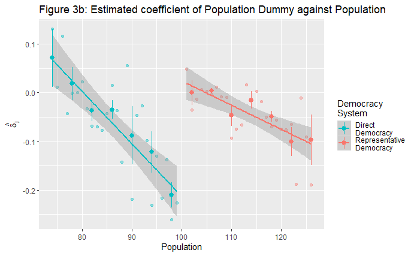

```r
########## 5.3 Replicating Figure 3 ##########
## Replicating for Figure 3
bw <- 27
df.fig3.left<-df.discon %>%
    filter(pop_run > 0 - bw & pop_run < 0)
df.fig3.right<-df.discon %>%
    filter(pop_run > 0 & pop_run < 0 + bw)
#str(df.fig3.left)

rev_plm2 <- plm(log_rev_dem~pop_run+dd_bi+dd_pop_run+factor(year), data = df.plm,index = c("id"), model = "within")
#Taking the fixed effects of the years from the model
rev_fix_year <- rev_plm2$coefficients[4:length(rev_plm2$coefficients)]
#rev_fix_year

# Cretaing the Years. Note that the element number of this vector year is the same as the def_fix_year
Year<-1989:2011
#Year
# Taking the fixed effects of the unit from the model
rev_fix_unit <- fixef(rev_plm2)
rev_fix_unit_e<-summary(rev_fix_unit)[,c("Estimate")]

# Extracting the IDs. Note that the element number of this vector ID is the same as the rev_fix_unit
ID<-strtoi(list.names(rev_fix_unit_e))

rev_left<-lm(log_rev_dem~as.factor(id)+as.factor(year)+as.factor(population),data=df.fig3.left)
#def_left$coefficients[661:686]
rev_coef_left<-rev_left$coefficients[675:700]
#rev_coef_left
rev_coef_left<-unname(rev_coef_left,force=TRUE)
rev_pop_left<-74:99
rev_id_left<-rep(1,length(rev_pop_left))
rev_left_t<-data.frame(rev_pop_left,rev_coef_left,rev_id_left)
rev_left_t<-setNames(rev_left_t,c("pop","coef","id"))

rev_right<-lm(log_rev_dem~as.factor(id)+as.factor(year)+as.factor(population),data=df.fig3.right)
#length(rev_right$coefficients)
rev_coef_right<-rev_right$coefficients[903:928]
rev_coef_right<-unname(rev_coef_right,force=TRUE)
#rev_coef_right
rev_pop_right<-101:126
rev_id_right<-rep(0,length(rev_pop_right))
rev_right_t<-data.frame(rev_pop_right,rev_coef_right,rev_id_right)
rev_right_t<-setNames(rev_right_t,c("pop","coef","id"))

# Binding the two tibbles
rev_rightleft<-rbind(rev_right_t,rev_left_t)
#Normalizing based upon the first bin of four observations (i.e. 101:104) to the right of the cutoff.
rev_rightleft<-rev_rightleft %>%
  mutate(coef=coef-mean(coef[1:3]))
#rev_rightleft

ggplot(rev_rightleft,aes(x=pop,y=coef,color = as.factor(id)))+
  geom_point(alpha = 0.4)+
  stat_smooth(method="lm")+
  stat_summary_bin(binwidth = 4)+
  ggtitle("Figure 3b: Estimated coefficient of Population Dummy against Population")+
  xlab("Population")+
  ylab(bquote(hat(delta[j])))+
  scale_colour_discrete(name="Democracy\nSystem",
                         breaks=c("1","0"),
                         labels=c("Direct\nDemocracy","Representative\nDemocracy"))
```

# CHAPTER SIX: Main Results - The Effect of Direct Democracy on Expenditures

## 6.1 Visual Inspection

A rough visual inspection of the effect of direct democracy on the logarithm of expenditures. It is observed that there is a higher change in the outcome variable at the cutoff.

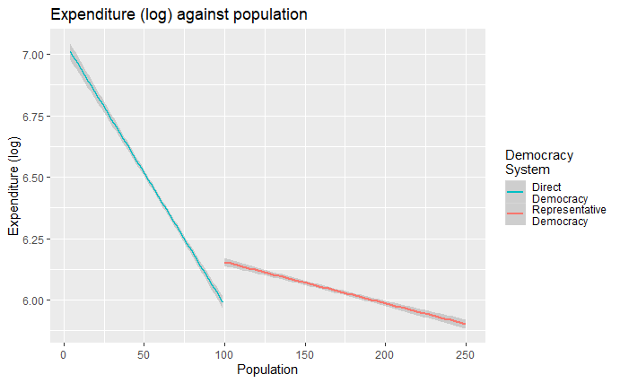

```r
########## 6.1 Visual Inspection ##########

df.discon %>%
 ggplot(aes(x = population, y = log_exp_dem, group = as.factor(dd), color = as.factor(dd)))+
  stat_smooth(method=lm)+
 ggtitle("Expenditure (log) against population")+
  xlab("Population")+
  ylab("Expenditure (log)")+
  scale_colour_discrete(name="Democracy\nSystem",
                         breaks=c("DD","RD"),
                         labels=c("Direct\nDemocracy","Representative\nDemocracy"))
```

## 6.2 Replicating Table 2 Results with PLM for Log Expenditures

Avoiding all other methods, I will use *rdbwselect_2014* and *plm* directly.

```r
########## 6.2 Using PLM to Estimate the Effect ##########

exp_rddrobust_bw <- rdbwselect_2014(y=df.discon$log_expenditures_c, x=df.discon$pop_run, c = 0 , kernel = "uni", bwselect = "IK")

# The Optimal Bandwidth, 1.5x and 0.5x
bw_exp3 <- exp_rddrobust_bw$bws[1]*(c(1,1.5,0.5))
#bw_exp3

######################### NORMAL BANDWIDTH ########################
## Subsetting the data to within the bandwidth
bw <- bw_exp3[1] # Selecting the right bandwidth
df.plm<-df.discon %>%
  filter(pop_run > 0 - bw & pop_run < 0 + bw) %>%
  mutate(dd_pop_run = dd_bi*pop_run)

## Running the linear PLM Model
exp_plm <- plm(log_exp_dem~pop_run+dd_bi+dd_pop_run, data = df.plm,index = c("id","year"), model = "within", effect = "twoways")
  summary(exp_plm)
```

```
Twoways effects Within Model

Call:
plm(formula = log_exp_dem ~ pop_run + dd_bi + dd_pop_run, data = df.plm,
    effect = "twoways", model = "within", index = c("id",
        "year"))

Unbalanced Panel: n = 1145, T = 1-24, N = 11975

Residuals:
     Min.   1st Qu.    Median   3rd Qu.      Max.
-3.286851 -0.219334 -0.023404  0.174471  3.651117

Coefficients:
              Estimate  Std. Error t-value  Pr(>|t|)
pop_run    -0.00631356  0.00085766 -7.3614 1.952e-13 ***
dd_bi      -0.07986995  0.01899343 -4.2051 2.630e-05 ***
dd_pop_run -0.00495591  0.00126988 -3.9027 9.572e-05 ***
---
Signif. codes:  0 ‘***’ 0.001 ‘**’ 0.01 ‘*’ 0.05 ‘.’ 0.1 ‘ ’ 1

Total Sum of Squares:    1970.3
Residual Sum of Squares: 1932.3
R-Squared:      0.01927
Adj. R-Squared: -0.086936
F-statistic: 70.763 on 3 and 10804 DF, p-value: < 2.22e-16
```

```r
exp_plm_c<-coeftest(exp_plm,vcov=vcovHC(exp_plm, method = "arellano",type="HC1", cluster = "group"))
## Running the Cubic PLM Model
exp_plm_cubic <- plm(log_exp_dem~pop_run+dd_bi+I(dd_bi*pop_run)+ + I(dd_bi*pop_run^2)+I(dd_bi*pop_run^3)+I(pop_run^2)+I(pop_run^3),
                     data = df.discon,index = c("id","year"), model = "within", effect = "twoways")
  summary(exp_plm_cubic)
```

```
Twoways effects Within Model

Call:
plm(formula = log_exp_dem ~ pop_run + dd_bi + I(dd_bi * pop_run) +
    +I(dd_bi * pop_run^2) + I(dd_bi * pop_run^3) + I(pop_run^2) +
    I(pop_run^3), data = df.discon, effect = "twoways",
    model = "within", index = c("id", "year"))

Unbalanced Panel: n = 2689, T = 1-24, N = 42078

Residuals:
      Min.    1st Qu.     Median    3rd Qu.       Max.
-15.400256  -0.231894  -0.028203   0.195245   4.916253

Coefficients:
                        Estimate  Std. Error t-value  Pr(>|t|)
pop_run              -5.7409e-03  7.5157e-04 -7.6385 2.247e-14 ***
dd_bi                -7.2929e-02  2.0423e-02 -3.5709 0.0003562 ***
I(dd_bi * pop_run)   -7.8357e-03  2.0311e-03 -3.8578 0.0001146 ***
I(dd_bi * pop_run^2) -2.4170e-04  5.6950e-05 -4.2441 2.200e-05 ***
I(dd_bi * pop_run^3) -3.7255e-06  4.6342e-07 -8.0392 9.292e-16 ***
I(pop_run^2)          1.2641e-05  1.1729e-05  1.0777 0.2811624
I(pop_run^3)          1.1998e-08  5.2525e-08  0.2284 0.8193251
---
Signif. codes:  0 ‘***’ 0.001 ‘**’ 0.01 ‘*’ 0.05 ‘.’ 0.1 ‘ ’ 1

Total Sum of Squares:    8162.6
Residual Sum of Squares: 7751.5
R-Squared:      0.050364
Adj. R-Squared: -0.015214
F-statistic: 298.204 on 7 and 39359 DF, p-value: < 2.22e-16
```

```r
  exp_plm_cubic_c<-coeftest(exp_plm_cubic,vcov=vcovHC(exp_plm_cubic, method = "arellano",type="HC1", cluster = "group"))

  ######################### 1.5x BANDWIDTH ########################
## Subsetting the data to within the bandwidth
bw <- bw_exp3[2] # Selecting the right bandwidth
df.plm15<-df.discon %>%
  filter(pop_run > 0 - bw & pop_run < 0 + bw) %>%
  mutate(dd_pop_run = dd_bi*pop_run)
#str(df.plm)

## Running the linear PLM Model
exp_plm15 <- plm(log_exp_dem~pop_run+dd_bi+dd_pop_run, data = df.plm15,index = c("id","year"), model = "within", effect = "twoways")
 summary(exp_plm15)
```

```
Twoways effects Within Model

Call:
plm(formula = log_exp_dem ~ pop_run + dd_bi + dd_pop_run, data = df.plm15,
    effect = "twoways", model = "within", index = c("id",
        "year"))

Unbalanced Panel: n = 1450, T = 1-24, N = 17691

Residuals:
      Min.    1st Qu.     Median    3rd Qu.       Max.
-14.600950  -0.221417  -0.023595   0.182123   3.806720

Coefficients:
              Estimate  Std. Error  t-value  Pr(>|t|)
pop_run    -0.00637694  0.00054678 -11.6627 < 2.2e-16 ***
dd_bi      -0.06053138  0.01653208  -3.6614 0.0002516 ***
dd_pop_run -0.00338075  0.00079652  -4.2444 2.204e-05 ***
---
Signif. codes:  0 ‘***’ 0.001 ‘**’ 0.01 ‘*’ 0.05 ‘.’ 0.1 ‘ ’ 1

Total Sum of Squares:    3272.4
Residual Sum of Squares: 3190
R-Squared:      0.025196
Adj. R-Squared: -0.063478
F-statistic: 139.702 on 3 and 16215 DF, p-value: < 2.22e-16
```

```r
 exp_plm15_c<-coeftest(exp_plm15,vcov=vcovHC(exp_plm15, method = "arellano",type="HC1", cluster = "group"))

######################### 0.5x BANDWIDTH ########################
## Subsetting the data to within the bandwidth
bw <- bw_exp3[3] # Selecting the right bandwidth
df.plm05<-df.discon %>%
  filter(pop_run > 0 - bw & pop_run < 0 + bw) %>%
  mutate(dd_pop_run = dd_bi*pop_run)

## Running the linear PLM Model
exp_plm05 <- plm(log_exp_dem~pop_run+dd_bi+dd_pop_run, data = df.plm05,index = c("id","year"), model = "within", effect = "twoways")
exp_plm05_c<-coeftest(exp_plm05,vcov=vcovHC(exp_plm05, method = "arellano",type="HC1", cluster = "group"))
  summary(exp_plm05)
```

```
Twoways effects Within Model

Call:
plm(formula = log_exp_dem ~ pop_run + dd_bi + dd_pop_run, data = df.plm05,
    effect = "twoways", model = "within", index = c("id",
        "year"))

Unbalanced Panel: n = 793, T = 1-24, N = 6001

Residuals:
     Min.   1st Qu.    Median   3rd Qu.      Max.
-2.481786 -0.203434 -0.020145  0.164537  3.468671

Coefficients:
              Estimate  Std. Error t-value  Pr(>|t|)
pop_run    -0.01207249  0.00228297 -5.2881 1.287e-07 ***
dd_bi      -0.08970364  0.02820241 -3.1807  0.001478 **
dd_pop_run -0.00096196  0.00353657 -0.2720  0.785631
---
Signif. codes:  0 ‘***’ 0.001 ‘**’ 0.01 ‘*’ 0.05 ‘.’ 0.1 ‘ ’ 1

Total Sum of Squares:    879.95
Residual Sum of Squares: 869.48
R-Squared:      0.011904
Adj. R-Squared: -0.14407
F-statistic: 20.8094 on 3 and 5182 DF, p-value: 2.132e-13
```

The table here presents the regression results for Log Expenditures. Standard errors are robust. Unit and time fixed effects are accounted for via the two-way fixed effects model.

```r
stargazer(exp_plm,exp_plm15,exp_plm05,exp_plm_cubic,
          se = list(exp_plm_c[,2],exp_plm15_c[,2],exp_plm05_c[,2],exp_plm_cubic_c[,2]),
          type = "html",
          title = "Rev (log) PLM Results",
          dep.var.caption = "Revenue",
          dep.var.labels = "Logarithm of Revenue (\u20AC)",
          omit = c("year"),
          column.labels = c("Optimized BW","1.5 x BW", "0.5 x BW", "Cubic Model (Full Data)"),
          suppress.errors = TRUE,
          notes = "BW = 27, 1.5 x BW = 41, 0.5 x BW = 13",
          order = c(2,1,3),
          covariate.labels = c("Direct democracy","Population","Direct democracy x Population"),
          digits = 4)
```

**Rev (log) PLM Results**

|  | Revenue |  |  |  |
| --- | --- | --- | --- | --- |
|  | Logarithm of Revenue (€) |  |  |  |
|  | Optimized BW | 1.5 x BW | 0.5 x BW | Cubic Model (Full Data) |
|  | (1) | (2) | (3) | (4) |
| Direct democracy | -0.0799*** | -0.0605** | -0.0897** | -0.0729** |
|  | (0.0269) | (0.0249) | (0.0406) | (0.0308) |
| Population | -0.0063*** | -0.0064*** | -0.0121*** | -0.0057*** |
|  | (0.0014) | (0.0009) | (0.0033) | (0.0014) |
| Direct democracy x Population | -0.0050** | -0.0034*** | -0.0010 |  |
|  | (0.0019) | (0.0013) | (0.0056) |  |
| I(dd_bi * pop_run) |  |  |  | -0.0078** |
|  |  |  |  | (0.0036) |
| I(dd_bi * pop_run2) |  |  |  | -0.0002** |
|  |  |  |  | (0.0001) |
| I(dd_bi * pop_run3) |  |  |  | -0.000004*** |
|  |  |  |  | (0.000001) |
| I(pop_run2) |  |  |  | 0.00001 |
|  |  |  |  | (0.00002) |
| I(pop_run3) |  |  |  | 0.0000 |
|  |  |  |  | (0.000000) |
| Observations | 11,975 | 17,691 | 6,001 | 42,078 |
| R<sup>2</sup> | 0.0193 | 0.0252 | 0.0119 | 0.0504 |
| Adjusted R<sup>2</sup> | -0.0869 | -0.0635 | -0.1441 | -0.0152 |
| F Statistic | 70.7630*** (df = 3; 10804) | 139.7021*** (df = 3; 16215) | 20.8094*** (df = 3; 5182) | 298.2041*** (df = 7; 39359) |
| *Note:* | p<0.1; p<0.05; p<0.01 |  |  |  |
|  | BW = 27, 1.5 x BW = 41, 0.5 x BW = 13 |  |  |  |

## 6.3 Replicating Figure 3 Results for Log Expenditure

Here, I used the second method involving dummy variables for each population as in Chapter 4.6.

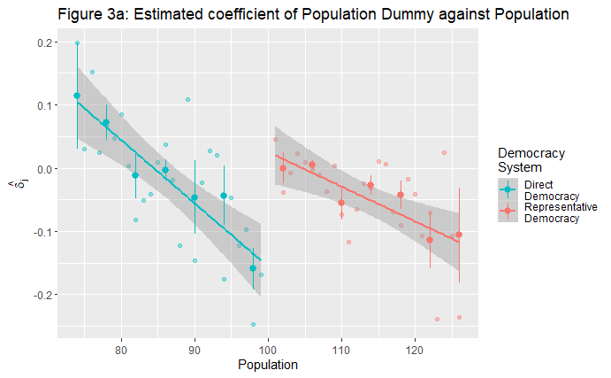

```r
########## 6.3 Replicating Figure 3 ##########
## Replicating for Figure 3
bw <- 27
df.fig3.left<-df.discon %>%
    filter(pop_run > 0 - bw & pop_run < 0)
df.fig3.right<-df.discon %>%
    filter(pop_run > 0 & pop_run < 0 + bw)
#str(df.fig3.left)
exp_plm2 <- plm(log_exp_dem~pop_run+dd_bi+dd_pop_run+factor(year), data = df.plm,index = c("id"), model = "within")
#Taking the fixed effects of the years from the model
exp_fix_year <- exp_plm2$coefficients[4:length(exp_plm2$coefficients)]
#exp_fix_year

# Cretaing the Years. Note that the element number of this vector year is the same as the def_fix_year
Year<-1989:2011
#Year
# Taking the fixed effects of the unit from the model
exp_fix_unit <- fixef(exp_plm2)
exp_fix_unit_e<-summary(exp_fix_unit)[,c("Estimate")]

# Extracting the IDs. Note that the element number of this vector ID is the same as the exp_fix_unit
ID<-strtoi(list.names(exp_fix_unit_e))

exp_left<-lm(log_exp_dem~as.factor(id)+as.factor(year)+as.factor(population),data=df.fig3.left)
#def_left$coefficients[661:686]
exp_coef_left<-exp_left$coefficients[675:700]
#exp_coef_left
exp_coef_left<-unname(exp_coef_left,force=TRUE)
exp_pop_left<-74:99
exp_id_left<-rep(1,length(exp_pop_left))
exp_left_t<-data.frame(exp_pop_left,exp_coef_left,exp_id_left)
exp_left_t<-setNames(exp_left_t,c("pop","coef","id"))

exp_right<-lm(log_exp_dem~as.factor(id)+as.factor(year)+as.factor(population),data=df.fig3.right)
#length(exp_right$coefficients)
exp_coef_right<-exp_right$coefficients[903:928]
exp_coef_right<-unname(exp_coef_right,force=TRUE)
#exp_coef_right
exp_pop_right<-101:126
exp_id_right<-rep(0,length(exp_pop_right))
exp_right_t<-data.frame(exp_pop_right,exp_coef_right,exp_id_right)
exp_right_t<-setNames(exp_right_t,c("pop","coef","id"))

# Binding the two tibbles
exp_rightleft<-rbind(exp_right_t,exp_left_t)
#Normalizing based upon the first bin of four observations (i.e. 101:104) to the right of the cutoff.
exp_rightleft<-exp_rightleft %>%
  mutate(coef=coef-mean(coef[1:3]))
#exp_rightleft

ggplot(exp_rightleft,aes(x=pop,y=coef,color = as.factor(id)))+
  geom_point(alpha = 0.4)+
  stat_smooth(method="lm")+
  stat_summary_bin(binwidth = 4)+
  ggtitle("Figure 3a: Estimated coefficient of Population Dummy against Population")+
  xlab("Population")+
  ylab(bquote(hat(delta[j])))+
    scale_colour_discrete(name="Democracy\nSystem",
                         breaks=c("1","0"),
                         labels=c("Direct\nDemocracy","Representative\nDemocracy"))
```

# CHAPTER SEVEN: Project Extension - Covariate Balance

However, I argue that the covariate balance ought to be conducted on the bandwidths run by each model. Theoretically, RDDs measure the presence of an imbalanced outcome variable at the cutoff, assuming as-if random assignment into treatment at the cutoff. As such, there could be imbalances in the covariates especially since we take all observations within the bandwidth conditional on the treatment to be homogenous. This homogeneity may not be the case.

## 7.1 Covariate Balance Analysis (within bandwidth)

For consistency with Figure 3, I analyzed the covariate balance within the log expenditures bandwidth of 27. I could also analyze the covariate balance for each of the bandwidths (Models 1,2,3,7) and the full dataset (Models 4,5,6)

```r
########## 7.1 Analysing the covariate balance within the bandwidth ##########

bw<-27 # Using the bandwidth of the expenditures for consistency
df.ext<-df.selected %>%
  mutate(pop_run = population - 99.5)%>%
  filter(pop_run > 0 - bw & pop_run < 0 + bw)%>%
  mutate(dd_bi = ifelse(dd == "RD",0,1))

#df.ext is the dataset here.
summaryC <- df.ext %>%
  group_by(dd)%>%
  select(-one_of("dd","l_log_revenues_c","l_log_expenditures_c","l_deficit_c", "id", "year", "log_revenues_c", "log_expenditures_c"))%>%
  summarise_all(funs(mean(., na.rm = T)))
colnames(summaryC)<-c("Democracy System","Expenditures (Euro per cap)",
         "Revenues (Euro per cap)",
         "Deficit (Euro per cap)",
         "PP Vote Sh (%)",
         "PSOE Vote Sh (%)",
         "IU Vote Sh (%)",
         "Votes Difference (%)",
         "Votes Winner (%)",
         "Turnout (%)",
         "Mean Age (years)",
         "Young (%)",
         "Middle-Aged (%)",
         "Old (%)",
         "Immigrants (%)",
         "EU Immigrants (%)",
         "Population (inhabitants)",
         "Unemployment (%)",
         "DD",
         "Running variable (Population)")
kable(summaryC, digits = 3) %>%
 kable_styling(bootstrap_options = c("striped","scale_down"), full_width = FALSE, position = "left")
```

| Democracy System | Expenditures (Euro per cap) | Revenues (Euro per cap) | Deficit (Euro per cap) | PP Vote Sh (%) | PSOE Vote Sh (%) | IU Vote Sh (%) | Votes Difference (%) | Votes Winner (%) | Turnout (%) | Mean Age (years) | Young (%) | Middle-Aged (%) | Old (%) | Immigrants (%) | EU Immigrants (%) | Population (inhabitants) | Unemployment (%) | DD | Running variable (Population) |
| --- | --- | --- | --- | --- | --- | --- | --- | --- | --- | --- | --- | --- | --- | --- | --- | --- | --- | --- | --- |
| RD | 634.879 | 608.833 | 26.046 | 53.356 | 30.183 | 3.152 | 31.556 | 59.832 | 78.628 | 53.342 | 8.879 | 53.266 | 37.856 | 2.684 | 45.287 | 112.532 | 2.062 | 0 | 13.032 |
| DD | 657.411 | 634.460 | 22.951 | 56.713 | 27.896 | 3.279 | 35.611 | 61.973 | 78.082 | 54.312 | 7.921 | 52.545 | 39.534 | 2.350 | 45.837 | 85.446 | 1.850 | 1 | -14.054 |

## 7.2 Attempt at Propensity Score Matching with Imputation

Due to missing data present, I am unable to immediately execute propensity score matching using the package *MatchIt*. As such, I use MICE or Multivariate Imputation By Chained Equations in order to impute the data. (*van Buuren, S., Groothuis-Oudshoorn, K. (2011). mice: Multivariate Imputation by Chained Equations in R. Journal of Statistical Software, 45(3), 1–67.*) The package will then create imputed values by estimating the values of the missing data. However, due to the extent of the missing data, I was unable to impute sufficient data to run matchit (which requires a complete dataset). Hence, I will not use this method moving forward.

```r
########## 7.2 Using Propensity Score Matching ##########
#df.ext is the dataset here; df.imp is the imputed dataset
library(mice)
library(VIM)
library(Zelig)

df_small<-df.ext[,-which(colMeans(is.na(df.ext))>0.05)]

imputed_Data <- mice(df_small, m=1, maxit = 2, method = 'pmm', seed = 500, remove_collinear = TRUE)
df.imp<-imputed_Data$data
df.imp<-data.frame(df.imp)
df_smallcheck<-df.imp[,which(colMeans(is.na(df.imp))>0.01)] #check for non-imputed values
df_smallcheck

head(df.imp)

m.out_near <- matchit(dd_bi ~ g_p_votes_pp + g_p_votes_psoe + g_p_votes_iu+g_p_diff+g_p_votes_winner+g_p_turnout+age_avg+sh_young+sh_adult+sh_old+sh_foreign+sh_eu+unemployment_rate+year,
    data = df.imp, method ="nearest", distance = "logit", replace = TRUE) # how to extract specific column names

summary(m.out_near)
plot(m.out_near, type = "jitter")
plot(m.out_near, type = "hist")

m.data2 <- match.data(m.out_near, distance = "pscore")
```

## 7.3 Covariate T-Tests between that of DD and RD Groups

Due to the inability to use propensity score matching, I instead resort to two-way t-tests to see if there are statistical differences between the covariate values of the direct democracy group and the representative democracy group within the bandwidth.

```r
########## 7.3 Using T-Tests Between DD and RD Groups within BW ##########
#df.ttest is the dataset here.

df.ttest<- df.ext %>%
  select(-one_of("dd","l_log_revenues_c","l_log_expenditures_c","l_deficit_c", "id", "year","pop_run"))

# Running multiple t-tests based on dd
# Assuming the variables are normally distributed.
ttests <- map(
  select(df.ttest,-c(dd_bi)),
  ~ t.test(.x ~ dd_bi, data = df.ttest)
)
#class(ttests)

library(broom) # For tidy
library(purrr)

# Compressing all the results into one table using tidy
tab<-map_df(ttests,tidy)

# Adding row names
names <- c("Expenditures (Euro per cap)","Revenues (Euro per cap)",
         "Deficit (Euro per cap)",
         "PP Vote Sh (%)",
         "PSOE Vote Sh (%)",
         "IU Vote Sh (%)",
         "Votes Difference (%)",
         "Votes Winner (%)",
         "Turnout (%)",
         "Mean Age (years)",
         "Young (%)",
         "Middle-Aged (%)",
         "Old (%)",
         "Immigrants (%)",
         "EU Immigrants (%)",
         "Population (inhabitants)",
         "Unemployment (%)",
         "Log Revenues",
         "Log Expenditures")
tab2<-add_column(tab,names)

# Adding significance levels
tab2<-tab2%>%
  mutate(siglevel = ifelse(p.value<0.05,ifelse(p.value<0.01,"<0.01","<0.05"),">=0.05"))

# Reordering the variables
tab2<-tab2%>%
  select(names,siglevel,p.value,everything())

# Adding column names
colnames(tab2)<- c("Variable","Sig. Level","P-Value","Mean Difference", "RD Group Mean", "DD Group Mean",
                   "T-Statistic","Parameter","Conf. Int (2.5%)","Conf. Int (97.5%)","Method","Type")
# Using kable
kable(tab2, digits = 3) %>%
 kable_styling(bootstrap_options = c("striped","scale_down"), position = "left")%>%
  row_spec(c(4,5,7,8,9,10,11,12,13,14,16,17),bold = T, color = "black",background ="orange")%>%
  row_spec(18, bold = T, color = "black",background = "yellow")%>%
  footnote(general = " All variables with a significance level < 0.01 is highlighted in orange whilst the lone variable with a significance level < 0.05 is highlighted in yellow.")
```

| Variable | Sig. Level | P-Value | Mean Difference | RD Group Mean | DD Group Mean | T-Statistic | Parameter | Conf. Int (2.5%) | Conf. Int (97.5%) | Method | Type |
| --- | --- | --- | --- | --- | --- | --- | --- | --- | --- | --- | --- |
| Expenditures (Euro per cap) | >=0.05 | 0.279 | -22.532 | 634.879 | 657.411 | -1.083 | 10918.064 | -63.321 | 18.258 | Welch Two Sample t-test | two.sided |
| Revenues (Euro per cap) | >=0.05 | 0.202 | -25.627 | 608.833 | 634.460 | -1.276 | 11113.988 | -64.980 | 13.726 | Welch Two Sample t-test | two.sided |
| Deficit (Euro per cap) | >=0.05 | 0.513 | 3.095 | 26.046 | 22.951 | 0.654 | 11379.284 | -6.182 | 12.373 | Welch Two Sample t-test | two.sided |
| PP Vote Sh (%) | <0.01 | 0.000 | -3.357 | 53.356 | 56.713 | -8.853 | 10355.841 | -4.100 | -2.614 | Welch Two Sample t-test | two.sided |
| PSOE Vote Sh (%) | <0.01 | 0.000 | 2.287 | 30.183 | 27.896 | 8.221 | 10115.609 | 1.742 | 2.833 | Welch Two Sample t-test | two.sided |
| IU Vote Sh (%) | >=0.05 | 0.116 | -0.128 | 3.152 | 3.279 | -1.572 | 7871.011 | -0.287 | 0.031 | Welch Two Sample t-test | two.sided |
| Votes Difference (%) | <0.01 | 0.000 | -4.054 | 31.556 | 35.611 | -9.894 | 9814.834 | -4.858 | -3.251 | Welch Two Sample t-test | two.sided |
| Votes Winner (%) | <0.01 | 0.000 | -2.141 | 59.832 | 61.973 | -8.619 | 9826.817 | -2.628 | -1.654 | Welch Two Sample t-test | two.sided |
| Turnout (%) | <0.01 | 0.001 | 0.546 | 78.628 | 78.082 | 3.347 | 9718.850 | 0.226 | 0.866 | Welch Two Sample t-test | two.sided |
| Mean Age (years) | <0.01 | 0.000 | -0.969 | 53.342 | 54.312 | -7.177 | 6589.230 | -1.234 | -0.705 | Welch Two Sample t-test | two.sided |
| Young (%) | <0.01 | 0.000 | 0.958 | 8.879 | 7.921 | 7.905 | 6637.372 | 0.720 | 1.196 | Welch Two Sample t-test | two.sided |
| Middle-Aged (%) | <0.01 | 0.001 | 0.720 | 53.266 | 52.545 | 3.434 | 6482.047 | 0.309 | 1.132 | Welch Two Sample t-test | two.sided |
| Old (%) | <0.01 | 0.000 | -1.678 | 37.856 | 39.534 | -6.378 | 6503.493 | -2.194 | -1.163 | Welch Two Sample t-test | two.sided |
| Immigrants (%) | <0.01 | 0.003 | 0.335 | 2.684 | 2.350 | 2.954 | 6957.741 | 0.113 | 0.556 | Welch Two Sample t-test | two.sided |
| EU Immigrants (%) | >=0.05 | 0.710 | -0.550 | 45.287 | 45.837 | -0.371 | 2688.328 | -3.455 | 2.354 | Welch Two Sample t-test | two.sided |
| Population (inhabitants) | <0.01 | 0.000 | 27.086 | 112.532 | 85.446 | 182.394 | 10426.750 | 26.795 | 27.377 | Welch Two Sample t-test | two.sided |
| Unemployment (%) | <0.01 | 0.000 | 0.212 | 2.062 | 1.850 | 4.803 | 7629.388 | 0.125 | 0.298 | Welch Two Sample t-test | two.sided |
| Log Revenues | <0.05 | 0.014 | -0.033 | 6.116 | 6.149 | -2.455 | 10151.327 | -0.059 | -0.007 | Welch Two Sample t-test | two.sided |
| Log Expenditures | >=0.05 | 0.072 | -0.025 | 6.142 | 6.167 | -1.797 | 10179.882 | -0.053 | 0.002 | Welch Two Sample t-test | two.sided |

Note:  
All variables with a significance level < 0.01 is highlighted in orange whilst the lone variable with a significance level < 0.05 is highlighted in yellow.

## 7.4 Conditioning on Covariates

Whilst I did the test on all covariates listed in Table 1 in the paper, it is noteworthy that we expect population to be statistically different between the two samples. Population, however, was added for completeness. The log revenues was taken to be statistically different. In spite of this, log expenditures was not statistically different in the two groups. This is in contrast to the RDD which showed a statistically significant difference at the cutoff, which used the same bandwidth as the tests in this chapter.

According to the DAG I drew, I should NOT condition on any of these covariates as they could only bias the estimate further by doing so. However, for argument and experimental sake, I will condition on these covariates to see any change in our estimates.

As such, I will attempt to see the different results for expenditures if I condition on these covariates.

```r
########## 7.4 Attempting to run the regression conditional on statistically significantly different covariates ##########
# df.plm is the data set used for plm here (within the correct bandwidths for expenditure)

## Running the linear PLM Model
without <- plm(log_exp_dem~pop_run+dd_bi+dd_pop_run, data = df.plm,index = c("id","year"), model = "within",effect = "twoways")
#  summary(without)
without_c<-coeftest(with,vcov=vcovHC(with, method = "arellano",type="HC1", cluster = "group"))
without_c
```

[output not shown]

```r
  #+sh_young+sh_adult+sh_old were omitted due to their unusually high coefficient values (>4000)
with <- plm(log_exp_dem~pop_run+dd_bi+dd_pop_run+g_p_votes_pp+g_p_votes_psoe+g_p_diff+g_p_votes_winner+g_p_turnout+age_avg+sh_foreign+unemployment_rate, data = df.plm,index = c("id","year"), model = "within",effect = "twoways")
#  summary(with)
with_c<-coeftest(with,vcov=vcovHC(with, method = "arellano",type="HC1", cluster = "group"))
with_c
```

```
t test of coefficients:

                     Estimate  Std. Error t value Pr(>|t|)
pop_run           -7.3298e-03  1.5279e-03 -4.7975 1.64e-06 ***
dd_bi             -6.0295e-02  3.0984e-02 -1.9460  0.05169 .
dd_pop_run        -2.6908e-03  2.2141e-03 -1.2153  0.22428
g_p_votes_pp      -4.0974e-04  2.0746e-03 -0.1975  0.84344
g_p_votes_psoe    -9.2792e-04  2.2011e-03 -0.4216  0.67336
g_p_diff          -2.8446e-03  2.4222e-03 -1.1744  0.24028
g_p_votes_winner   3.0329e-03  4.4295e-03  0.6847  0.49355
g_p_turnout        1.5929e-04  1.3082e-03  0.1218  0.90309
age_avg           -1.0124e-02  4.1738e-03 -2.4255  0.01531 *
sh_foreign        -6.4543e-05  2.4108e-03 -0.0268  0.97864
unemployment_rate -3.2256e-03  4.4858e-03 -0.7191  0.47212
---
Signif. codes:  0 ‘***’ 0.001 ‘**’ 0.01 ‘*’ 0.05 ‘.’ 0.1 ‘ ’ 1
```

The table below compares the original model and the model that controls for other covariates deemed to have statistically significant difference between observations in RD and DD. The most significant observation is that the democracy variable is now no longer as statistically significant as before (P-val = 0.05169)

```r
stargazer(without,with,
          se = list(without_c[,2],with_c[,2]),
          type = "html",
          title = "With and without controlling for covariates",
          dep.var.caption = "Expenditure",
          dep.var.labels = "Logarithm of Expenditure (\u20AC)",
#          omit = c("year"),
          column.labels = c("Original","Controlled"),
          suppress.errors = TRUE,
 #         notes = "BW = 25, 1.5 x BW = 38, 0.5 x BW = 12",
#          order = c(2,1,3),
 #         covariate.labels = c("Direct democracy","Population","Direct democracy x Population"),
          digits = 4)
```

**With and without controlling for covariates**

|  | Expenditure |  |
| --- | --- | --- |
|  | Logarithm of Expenditure (€) |  |
|  | Original | Controlled |
|  | (1) | (2) |
| pop_run | -0.0063*** | -0.0073*** |
|  | (0.0015) | (0.0015) |
| dd_bi | -0.0799*** | -0.0603* |
|  | (0.0310) | (0.0310) |
| dd_pop_run | -0.0050** | -0.0027 |
|  | (0.0022) | (0.0022) |
| g_p_votes_pp |  | -0.0004 |
|  |  | (0.0021) |
| g_p_votes_psoe |  | -0.0009 |
|  |  | (0.0022) |
| g_p_diff |  | -0.0028 |
|  |  | (0.0024) |
| g_p_votes_winner |  | 0.0030 |
|  |  | (0.0044) |
| g_p_turnout |  | 0.0002 |
|  |  | (0.0013) |
| age_avg |  | -0.0101** |
|  |  | (0.0042) |
| sh_foreign |  | -0.0001 |
|  |  | (0.0024) |
| unemployment_rate |  | -0.0032 |
|  |  | (0.0045) |
| Observations | 11,975 | 8,007 |
| R<sup>2</sup> | 0.0193 | 0.0198 |
| Adjusted R<sup>2</sup> | -0.0869 | -0.1264 |
| F Statistic | 70.7630*** (df = 3; 10804) | 12.8003*** (df = 11; 6967) |
| *Note:* | p<0.1; p<0.05; p<0.01 |  |

# CHAPTER EIGHT: Project Extension - Estimating Revenues and Expenditures RDD Effects (without logarithms)

The project made used of of the logarithm of expenditures and revenues in order to show statistically significant results. I want to explore the regression results. As such, I replicate the process created for the linear model (first model in Table 2) to investigate if we may still obtain comparable results.

## 8.1 IK Bandwidth, Data Subsetting & PLM

```r
########## 8.1 IK Bandwidth, Data Subsetting & PLM  ##########
## Obtaining ideal bandwidths for each model
bw_rev_Nm <- rdbwselect_2014(y=df.gdp$revenues_c, x=df.gdp$pop_run, c = 0 , kernel = "uni", bwselect = "IK")
bw_rev_N <- bw_rev_Nm$bws[1]*(c(1,1.5,0.5))
bw_exp_Nm <- rdbwselect_2014(y=df.gdp$expenditures_c, x=df.gdp$pop_run, c = 0 , kernel = "uni", bwselect = "IK")
bw_exp_N <- bw_exp_Nm$bws[1]*(c(1,1.5,0.5))

## Subsetting the data
df.rev_N<-df.gdp %>%
  filter(pop_run > 0 - bw_rev_N[1] & pop_run < 0 + bw_rev_N[1]) %>%
  mutate(dd_pop_run = dd_bi*pop_run)
df.exp_N<-df.gdp %>%
  filter(pop_run > 0 - bw_exp_N[1] & pop_run < 0 + bw_exp_N[1]) %>%
  mutate(dd_pop_run = dd_bi*pop_run)

## Running the linear PLM Models

plm.rev_N <- plm(revenues_c~pop_run+dd_bi+dd_pop_run, data = df.rev_N,index = c("id","year"), model = "within", effect = "twoways")
  plm.rev_N_se<-coeftest(plm.rev_N,vcov=vcovHC(plm.rev_N, method = "arellano",type="HC1", cluster = "group"))
  summary(plm.rev_N) # Check here for new model
```

```
Twoways effects Within Model

Call:
plm(formula = revenues_c ~ pop_run + dd_bi + dd_pop_run, data = df.rev_N,
    effect = "twoways", model = "within", index = c("id",
        "year"))

Unbalanced Panel: n = 1269, T = 1-24, N = 14007

Residuals:
     Min.   1st Qu.    Median   3rd Qu.      Max.
-6334.839  -137.106   -12.721    94.293 52192.095

Coefficients:
            Estimate Std. Error t-value Pr(>|t|)
pop_run     -0.97127    1.51622 -0.6406   0.5218
dd_bi      -15.04559   37.69540 -0.3991   0.6898
dd_pop_run  -3.45021    2.19547 -1.5715   0.1161

Total Sum of Squares:    1.0562e+10
Residual Sum of Squares: 1.0554e+10
R-Squared:      0.00067959
Adj. R-Squared: -0.10104
F-statistic: 2.88161 on 3 and 12712 DF, p-value: 0.034446
```

```r
#  summary(rev_plm)   # Check here for old model

plm.exp_N <- plm(expenditures_c~pop_run+dd_bi+dd_pop_run, data = df.exp_N,index = c("id","year"), model = "within", effect = "twoways")
  plm.exp_N_se<-coeftest(plm.exp_N,vcov=vcovHC(plm.exp_N, method = "arellano",type="HC1", cluster = "group"))
  summary(plm.exp_N) # Check here for new model
```

```
Twoways effects Within Model

Call:
plm(formula = expenditures_c ~ pop_run + dd_bi + dd_pop_run,
    data = df.exp_N, effect = "twoways", model = "within",
    index = c("id", "year"))

Unbalanced Panel: n = 1244, T = 1-24, N = 13601

Residuals:
     Min.   1st Qu.    Median   3rd Qu.      Max.
-6937.043  -162.450   -18.482   105.701 52118.821

Coefficients:
            Estimate Std. Error t-value Pr(>|t|)
pop_run     -0.93637    1.65211 -0.5668   0.5709
dd_bi      -11.53785   40.16404 -0.2873   0.7739
dd_pop_run  -2.93069    2.40153 -1.2203   0.2224

Total Sum of Squares:    1.1209e+10
Residual Sum of Squares: 1.1204e+10
R-Squared:      0.00047718
Adj. R-Squared: -0.10239
F-statistic: 1.96229 on 3 and 12331 DF, p-value: 0.11731
```

```r
#  summary(exp_plm)   # Check here for old model
```

## 8.2 Tables for Overall Results

Here, it is observed that for the non-log models, the RDD causal estimates of direct democracy are no longer statistically significant. The *R^2* values have decreased significantly, along with the F-statistic. Firstly, the bandwidth has increased slightly (eg. from 25 to 32 for the revenue modelsand from 27 to 32 for the expenditure models). As it took it more values, it estimated a much higher value of LATE (vis-a-vis the values in the original models). However, it also became non-statistically significant. This could be the reason for the author using the logarithm of revenue and expenditure to show statistically significant results. This could arise because the results are only statistically different between the two groups at the bandwidth on a log scale but not on a linear scale.

```r
stargazer(rev_plm,plm.rev_N,exp_plm,plm.exp_N,
          se = list(rev_plm_c[,2],plm.rev_N_se[,2],exp_plm_c[,2],plm.exp_N_se[,2]),
          type = "html",
          title = "Comparing RDD Results with Log and non-Log Outcome Variables",
          dep.var.labels = c("Logarithm of Revenue","Revenue","Logarithm of Expenditure","Expenditure"),
          omit = c("year"),
          column.labels = c("Original","Non-Log","Original","Non-Log"),
          #suppress.errors = TRUE,
          notes = "~(1) BW=25, (2) BW = 32, (3) BW = 27, (4) BW = 32",
          order = c(2,1,3),
          covariate.labels = c("Direct democracy","Population","Direct democracy x Population"),
          digits = 4)
```

**Comparing RDD Results with Log and non-Log Outcome Variables**

|  | *Dependent variable:* |  |  |  |
| --- | --- | --- | --- | --- |
|  | Logarithm of Revenue | Revenue | Logarithm of Expenditure | Expenditure |
|  | Original | Non-Log | Original | Non-Log |
|  | (1) | (2) | (3) | (4) |
| Direct democracy | -0.0521** | -15.0456 | -0.0799*** | -11.5379 |
|  | (0.0258) | (53.3294) | (0.0269) | (55.6047) |
| Population | -0.0057*** | -0.9713 | -0.0063*** | -0.9364 |
|  | (0.0016) | (1.8041) | (0.0014) | (2.0170) |
| Direct democracy x Population | -0.0034 | -3.4502 | -0.0050** | -2.9307 |
|  | (0.0021) | (2.4900) | (0.0019) | (2.7305) |
| Observations | 10,662 | 14,007 | 11,975 | 13,601 |
| R<sup>2</sup> | 0.0166 | 0.0007 | 0.0193 | 0.0005 |
| Adjusted R<sup>2</sup> | -0.0976 | -0.1010 | -0.0869 | -0.1024 |
| F Statistic | 53.6798*** (df = 3; 9552) | 2.8816** (df = 3; 12712) | 70.7630*** (df = 3; 10804) | 1.9623 (df = 3; 12331) |
| *Note:* | p<0.1; p<0.05; p<0.01 |  |  |  |
|  | ~(1) BW=25, (2) BW = 32, (3) BW = 27, (4) BW = 32 |  |  |  |

# CHAPTER NINE: Project Extension - Sensitivity of Regression Estimates to GDP Deflators (External GDP Deflator Data)

## 9.1 Obtaining GDP Deflators and Calculating Nominal Values

```r
## Spain GDP Deflator from World Bank
#spain_gdpdeflator <- read.csv("spain_gdpdeflator.csv", stringsAsFactors = FALSE)
#spain_gdpdeflator
#colnames(spain_gdpdeflator) <- "GDP Deflator"
#gdpdef_t <- spain_gdpdeflator[2:length(spain_gdpdeflator)]
#str(gdpdef_t)
#year = seq(1961,2019, by = 1)
#year_t <- tibble(year)
#colnames(year_t) <- "Year"
#bind_cols(gdpdef_t,year_t)
```

```r
########## 9.1 Downloading GDP Deflators and Calculating Nominal Values ##########
# Obtaining all values for years and the relevant gdp deflators from World Bank
year<-c(1961,1962,1963,1964,1965,1966,1967,1968,1969,1970,1971,1972,1973,1974,1975,1976,1977,1978,1979,1980,1981,1982,1983,1984,1985,1986,1987,1988,1989,1990,1991,1992,1993,1994,1995,1996,1997,1998,1999,2000,2001,2002,2003,2004,2005,2006,2007,2008,2009,2010,2011,2012,2013,2014,2015,2016,2017,2018)
gdpdef<-c(2.466389754,6.095841623,7.84537469,6.254319615,9.164866647,8.17374336,8.537719088,5.911130109,5.133250642,8.768999111,7.846021338,8.517924864,11.8495953,15.94510943,16.78178182,16.48992178,23.38307,20.63104227,16.93163151,13.35482707,12.35119229,13.58232336,11.88424572,10.86473371,8.595479445,10.87881648,5.944198329,5.936126203,6.896194095,7.326251168,6.935139483,6.710771209,4.537241246,3.879841995,4.933129725,3.4707213,2.381828025,2.532759835,2.664837615,3.276074469,4.079865676,4.114985296,3.918908845,3.921275695,4.149491286,3.978200117,3.331139602,2.135441392,0.252533821,0.16041859,0.028968199,0.067950146,0.353610345,-0.19498388,0.513159948,0.293784948,1.236606788,0.987738161)/100
gdpdef_t<-tibble(year,gdpdef)

# Subsetting for this dataset
gdpdef_small<- gdpdef_t%>%
  filter(year>=1988 & year<=2011)

# Since each gdp deflator is the real value with respect to the previous year, the actual value to divide the nominal values must be multiplied by all previous values.
# Nom here, then is the overall gdp deflator

nom <- rep(1,dim(gdpdef_small)[1]) # Creating a vector of ones
count <- 0
for (i in 2:dim(gdpdef_small)[1])
{
nom[i] <- (gdpdef_small$gdpdef[i]+1)*nom[i-1]
count <- count+1
}

# Using our old dataset to retrieve the nominal values.
# For consistency again, I used the expenditures dataset
df.gdp<-df.selected %>%
  mutate(pop_run = population - 99.5)%>%
  mutate(dd_bi = ifelse(dd == "RD",0,1))

# Creating vectors of ones
df.gdp$nomfac<-rep(1,dim(df.gdp)[1])
df.gdp$deficit_nom<-rep(1,dim(df.gdp)[1])
df.gdp$exp_nom<-rep(1,dim(df.gdp)[1])
df.gdp$rev_nom<-rep(1,dim(df.gdp)[1])

## Calculating Nominal Values
# Looping to calculate the nominal values
for (i in 1:dim(df.gdp)[1])
{
df.gdp$nomfac[i] <- nom[df.gdp$year[i] == gdpdef_small$year]
df.gdp$deficit_nom[i] <- df.gdp$deficit_c[i] * df.gdp$nomfac[i]
df.gdp$exp_nom[i] <- 10^df.gdp$log_expenditures_c[i] * df.gdp$nomfac[i]
df.gdp$rev_nom[i] <- 10^df.gdp$log_revenues_c[i] * df.gdp$nomfac[i]
count <- count+1
}

# Looping to calculate the nominal values
for (i in 1:dim(df.gdp)[1])
{
df.gdp$nomfac[i] <- nom[df.gdp$year[i] == gdpdef_small$year]
df.gdp$deficit_nom[i] <- df.gdp$deficit_c[i] * df.gdp$nomfac[i]
df.gdp$exp_nom[i] <- 10^df.gdp$log_expenditures_c[i] * df.gdp$nomfac[i]
df.gdp$rev_nom[i] <- 10^df.gdp$log_revenues_c[i] * df.gdp$nomfac[i]
count <- count+1
}
```

## 9.2 Running PLM for Economic Variables Adjusted for 1% HIGHER GDP Deflator

First, I calculate the relevant economic variables adjusted for a 1% higher GDP deflator across all years. As such, the nominal value is divided by the elevated GDP deflator. Thereafter, I ran individual models to re-calculate optimal bandwidths, subsetting the values within those optimal bandwidths, and running a two-way fixed effects model whilst providing robust standard errors on municipalities. Thereafter, I compare and contrast the results for deficit, logarithm of revenues and logarithm of expenditure.

```r
########## 9.2 Running PLM for Economic Variables Adjusted for 1% Higher GDP Deflator ##########
# If the GDP Deflator was in fact one percent higher (cet.par), the difference between values will then become smaller. Therefore, the RDD ought to decrease.
for (i in 1:dim(df.gdp)[1])
{
df.gdp$deficit_h[i] <- df.gdp$deficit_nom[i] / (df.gdp$nomfac[i]+0.01)
df.gdp$log_exp_h[i] <- log10(df.gdp$exp_nom[i] / (df.gdp$nomfac[i]+0.01))
df.gdp$log_rev_h[i] <- log10(df.gdp$rev_nom[i] / (df.gdp$nomfac[i]+0.01))
count <- count+1
}
```

```
Unknown or uninitialised column: 'deficit_h'.Unknown or uninitialised column: 'log_exp_h'.Unknown or uninitialised column: 'log_rev_h'.
```

```r
## Obtaining ideal bandwidths individually for each model
bw_def_hm <- rdbwselect_2014(y=df.gdp$deficit_h, x=df.gdp$pop_run, c = 0 , kernel = "uni", bwselect = "IK")
bw_def_h <- bw_def_hm$bws[1]*(c(1,1.5,0.5))
bw_rev_hm <- rdbwselect_2014(y=df.gdp$log_rev_h, x=df.gdp$pop_run, c = 0 , kernel = "uni", bwselect = "IK")
bw_rev_h <- bw_rev_hm$bws[1]*(c(1,1.5,0.5))
bw_exp_hm <- rdbwselect_2014(y=df.gdp$log_exp_h, x=df.gdp$pop_run, c = 0 , kernel = "uni", bwselect = "IK")
bw_exp_h <- bw_exp_hm$bws[1]*(c(1,1.5,0.5))

## Subsetting the data
df.def_h<-df.gdp %>%
  filter(pop_run > 0 - bw_def_h[1] & pop_run < 0 + bw_def_h[1]) %>%
  mutate(dd_pop_run = dd_bi*pop_run)
df.rev_h<-df.gdp %>%
  filter(pop_run > 0 - bw_rev_h[1] & pop_run < 0 + bw_rev_h[1]) %>%
  mutate(dd_pop_run = dd_bi*pop_run)
df.exp_h<-df.gdp %>%
  filter(pop_run > 0 - bw_exp_h[1] & pop_run < 0 + bw_exp_h[1]) %>%
  mutate(dd_pop_run = dd_bi*pop_run)

## Running the linear PLM Models

plm.def_h <- plm(deficit_h~pop_run+dd_bi+dd_pop_run, data = df.def_h,index = c("id","year"), model = "within", effect = "twoways")
  plm.def_h_se<-coeftest(plm.def_h,vcov=vcovHC(plm.def_h, method = "arellano",type="HC1", cluster = "group"))
  summary(plm.def_h) # Check here for new model
```

```
Twoways effects Within Model

Call:
plm(formula = deficit_h ~ pop_run + dd_bi + dd_pop_run, data = df.def_h,
    effect = "twoways", model = "within", index = c("id",
        "year"))

Unbalanced Panel: n = 2286, T = 1-24, N = 34617

Residuals:
       Min.     1st Qu.      Median     3rd Qu.        Max.
-10395.4594    -38.0593     -6.8783     14.8122   7694.1902

Coefficients:
            Estimate Std. Error t-value Pr(>|t|)
pop_run     0.030037   0.119572  0.2512 0.801658
dd_bi      -7.835416   7.450449 -1.0517 0.292959
dd_pop_run -0.665279   0.245499 -2.7099 0.006734 **
---
Signif. codes:  0 ‘***’ 0.001 ‘**’ 0.01 ‘*’ 0.05 ‘.’ 0.1 ‘ ’ 1

Total Sum of Squares:    1932200000
Residual Sum of Squares: 1931700000
R-Squared:      0.00024535
Adj. R-Squared: -0.071274
F-statistic: 2.64267 on 3 and 32305 DF, p-value: 0.047541
```

```r
#  summary(def_plm)   # Check here for old model

plm.rev_h <- plm(log_rev_h~pop_run+dd_bi+dd_pop_run+factor(year), data = df.rev_h,index = c("id","year"), model = "within", effect = "twoways")
  plm.rev_h_se<-coeftest(plm.rev_h,vcov=vcovHC(plm.rev_h, method = "arellano",type="HC1", cluster = "group"))
  summary(plm.rev_h) # Check here for new model
```

```
Twoways effects Within Model

Call:
plm(formula = log_rev_h ~ pop_run + dd_bi + dd_pop_run + factor(year),
    data = df.rev_h, effect = "twoways", model = "within",
    index = c("id", "year"))

Unbalanced Panel: n = 1084, T = 1-24, N = 10662

Residuals:
     Min.   1st Qu.    Median   3rd Qu.      Max.
-1.880985 -0.181492 -0.017642  0.146828  3.639287

Coefficients:
              Estimate  Std. Error t-value  Pr(>|t|)
pop_run    -0.00565769  0.00086841 -6.5150 7.637e-11 ***
dd_bi      -0.05212404  0.01763285 -2.9561  0.003123 **
dd_pop_run -0.00343292  0.00130792 -2.6247  0.008686 **
---
Signif. codes:  0 ‘***’ 0.001 ‘**’ 0.01 ‘*’ 0.05 ‘.’ 0.1 ‘ ’ 1

Total Sum of Squares:    1308.9
Residual Sum of Squares: 1287.2
R-Squared:      0.01658
Adj. R-Squared: -0.097597
F-statistic: 53.6798 on 3 and 9552 DF, p-value: < 2.22e-16
```

```r
#  summary(rev_plm)   # Check here for old model

plm.exp_h <- plm(log_exp_h~pop_run+dd_bi+dd_pop_run, data = df.exp_h,index = c("id","year"), model = "within", effect = "twoways")
  plm.exp_h_se<-coeftest(plm.exp_h,vcov=vcovHC(plm.exp_h, method = "arellano",type="HC1", cluster = "group"))
  summary(plm.exp_h) # Check here for new model
```

```
Twoways effects Within Model

Call:
plm(formula = log_exp_h ~ pop_run + dd_bi + dd_pop_run, data = df.exp_h,
    effect = "twoways", model = "within", index = c("id",
        "year"))

Unbalanced Panel: n = 1145, T = 1-24, N = 11975

Residuals:
     Min.   1st Qu.    Median   3rd Qu.      Max.
-3.286851 -0.219334 -0.023404  0.174471  3.651117

Coefficients:
              Estimate  Std. Error t-value  Pr(>|t|)
pop_run    -0.00631356  0.00085766 -7.3614 1.952e-13 ***
dd_bi      -0.07986995  0.01899343 -4.2051 2.630e-05 ***
dd_pop_run -0.00495591  0.00126988 -3.9027 9.572e-05 ***
---
Signif. codes:  0 ‘***’ 0.001 ‘**’ 0.01 ‘*’ 0.05 ‘.’ 0.1 ‘ ’ 1

Total Sum of Squares:    1970.3
Residual Sum of Squares: 1932.3
R-Squared:      0.01927
Adj. R-Squared: -0.086936
F-statistic: 70.763 on 3 and 10804 DF, p-value: < 2.22e-16
```

```r
#  summary(exp_plm)   # Check here for old model
```

## 9.3 Running PLM for Economic Variables Adjusted for 1% LOWER GDP Deflator

```r
########## 9.3 Running PLM for Economic Variables Adjusted for 1% LOWER GDP Deflator ##########
# Similarly, if the GDP Deflator was in fact one percent lower (cet.par), the difference between values will then become larger. Therefore, the RDD ought to increase.

for (i in 1:dim(df.gdp)[1])
{
df.gdp$deficit_l[i] <- df.gdp$deficit_nom[i] / (df.gdp$nomfac[i]-0.01)
df.gdp$log_exp_l[i] <- log10(df.gdp$exp_nom[i] / (df.gdp$nomfac[i]-0.01))
df.gdp$log_rev_l[i] <- log10(df.gdp$rev_nom[i] / (df.gdp$nomfac[i]-0.01))
count <- count+1
}
```

```
Unknown or uninitialised column: 'deficit_l'.Unknown or uninitialised column: 'log_exp_l'.Unknown or uninitialised column: 'log_rev_l'.
```

```r
# Running the PLM for LINEAR model with the OPTIMAL BW

bw_def_lm <- rdbwselect_2014(y=df.gdp$deficit_l, x=df.gdp$pop_run, c = 0 , kernel = "uni", bwselect = "IK")
bw_def_l <- bw_def_lm$bws[1]*(c(1,1.5,0.5))
bw_rev_lm <- rdbwselect_2014(y=df.gdp$log_rev_l, x=df.gdp$pop_run, c = 0 , kernel = "uni", bwselect = "IK")
bw_rev_l <- bw_rev_lm$bws[1]*(c(1,1.5,0.5))
bw_exp_lm <- rdbwselect_2014(y=df.gdp$log_exp_l, x=df.gdp$pop_run, c = 0 , kernel = "uni", bwselect = "IK")
bw_exp_l <- bw_exp_lm$bws[1]*(c(1,1.5,0.5))

## Subsetting the data
df.def_l<-df.gdp %>%
  filter(pop_run > 0 - bw_def_l[1] & pop_run < 0 + bw_def_l[1]) %>%
  mutate(dd_pop_run = dd_bi*pop_run)
df.rev_l<-df.gdp %>%
  filter(pop_run > 0 - bw_rev_l[1] & pop_run < 0 + bw_rev_l[1]) %>%
  mutate(dd_pop_run = dd_bi*pop_run)
df.exp_l<-df.gdp %>%
  filter(pop_run > 0 - bw_exp_l[1] & pop_run < 0 + bw_exp_l[1]) %>%
  mutate(dd_pop_run = dd_bi*pop_run)

## Running the linear PLM Models

plm.def_l <- plm(deficit_l~pop_run+dd_bi+dd_pop_run, data = df.def_l,index = c("id","year"), model = "within", effect = "twoways")
  plm.def_l_se<-coeftest(plm.def_l,vcov=vcovHC(plm.def_l, method = "arellano",type="HC1", cluster = "group"))
  summary(plm.def_h) # Check here for new model
```

```
Twoways effects Within Model

Call:
plm(formula = deficit_h ~ pop_run + dd_bi + dd_pop_run, data = df.def_h,
    effect = "twoways", model = "within", index = c("id",
        "year"))

Unbalanced Panel: n = 2286, T = 1-24, N = 34617

Residuals:
       Min.     1st Qu.      Median     3rd Qu.        Max.
-10395.4594    -38.0593     -6.8783     14.8122   7694.1902

Coefficients:
            Estimate Std. Error t-value Pr(>|t|)
pop_run     0.030037   0.119572  0.2512 0.801658
dd_bi      -7.835416   7.450449 -1.0517 0.292959
dd_pop_run -0.665279   0.245499 -2.7099 0.006734 **
---
Signif. codes:  0 ‘***’ 0.001 ‘**’ 0.01 ‘*’ 0.05 ‘.’ 0.1 ‘ ’ 1

Total Sum of Squares:    1932200000
Residual Sum of Squares: 1931700000
R-Squared:      0.00024535
Adj. R-Squared: -0.071274
F-statistic: 2.64267 on 3 and 32305 DF, p-value: 0.047541
```

```r
#  summary(def_plm)   # Check here for old model

plm.rev_l <- plm(log_rev_l~pop_run+dd_bi+dd_pop_run+factor(year), data = df.rev_l,index = c("id","year"), model = "within", effect = "twoways")
  plm.rev_l_se<-coeftest(plm.rev_l,vcov=vcovHC(plm.rev_l, method = "arellano",type="HC1", cluster = "group"))
  summary(plm.rev_h) # Check here for new model
```

```
Twoways effects Within Model

Call:
plm(formula = log_rev_h ~ pop_run + dd_bi + dd_pop_run + factor(year),
    data = df.rev_h, effect = "twoways", model = "within",
    index = c("id", "year"))

Unbalanced Panel: n = 1084, T = 1-24, N = 10662

Residuals:
     Min.   1st Qu.    Median   3rd Qu.      Max.
-1.880985 -0.181492 -0.017642  0.146828  3.639287

Coefficients:
              Estimate  Std. Error t-value  Pr(>|t|)
pop_run    -0.00565769  0.00086841 -6.5150 7.637e-11 ***
dd_bi      -0.05212404  0.01763285 -2.9561  0.003123 **
dd_pop_run -0.00343292  0.00130792 -2.6247  0.008686 **
---
Signif. codes:  0 ‘***’ 0.001 ‘**’ 0.01 ‘*’ 0.05 ‘.’ 0.1 ‘ ’ 1

Total Sum of Squares:    1308.9
Residual Sum of Squares: 1287.2
R-Squared:      0.01658
Adj. R-Squared: -0.097597
F-statistic: 53.6798 on 3 and 9552 DF, p-value: < 2.22e-16
```

```r
#  summary(rev_plm)   # Check here for old model

plm.exp_l <- plm(log_exp_l~pop_run+dd_bi+dd_pop_run, data = df.exp_l,index = c("id","year"), model = "within", effect = "twoways")
  plm.exp_l_se<-coeftest(plm.exp_l,vcov=vcovHC(plm.exp_l, method = "arellano",type="HC1", cluster = "group"))
  summary(plm.exp_h) # Check here for new model
```

```
Twoways effects Within Model

Call:
plm(formula = log_exp_h ~ pop_run + dd_bi + dd_pop_run, data = df.exp_h,
    effect = "twoways", model = "within", index = c("id",
        "year"))

Unbalanced Panel: n = 1145, T = 1-24, N = 11975

Residuals:
     Min.   1st Qu.    Median   3rd Qu.      Max.
-3.286851 -0.219334 -0.023404  0.174471  3.651117

Coefficients:
              Estimate  Std. Error t-value  Pr(>|t|)
pop_run    -0.00631356  0.00085766 -7.3614 1.952e-13 ***
dd_bi      -0.07986995  0.01899343 -4.2051 2.630e-05 ***
dd_pop_run -0.00495591  0.00126988 -3.9027 9.572e-05 ***
---
Signif. codes:  0 ‘***’ 0.001 ‘**’ 0.01 ‘*’ 0.05 ‘.’ 0.1 ‘ ’ 1

Total Sum of Squares:    1970.3
Residual Sum of Squares: 1932.3
R-Squared:      0.01927
Adj. R-Squared: -0.086936
F-statistic: 70.763 on 3 and 10804 DF, p-value: < 2.22e-16
```

```r
#  summary(exp_plm)   # Check here for old model
```

## 9.4 Tables for Overall Results

```r
stargazer(def_plm,plm.def_h,plm.def_l,
          se = list(def_plm_c[,2],plm.def_h_se[,2],plm.def_l_se[,2]),
          type = "html",
          title = "Deficit PLM Results with Differing GDP Deflators",
          dep.var.caption = "Deficit",
          omit = c("year"),
          column.labels = c("Current GDP Deflator","High GDP Deflator (+1% for all years","Low GDP Deflator (-1% for all years)"),
          suppress.errors = TRUE,
          notes = "BW = 98, except the third model, where BW = 97",
          order = c(2,1,3),
          covariate.labels = c("Direct democracy","Population","Direct democracy x Population"),
          digits = 4)
```

**Deficit PLM Results with Differing GDP Deflators**

|  | Deficit |  |  |
| --- | --- | --- | --- |
|  | deficit_c_dem | deficit_h | deficit_l |
|  | Current GDP Deflator | High GDP Deflator (+1% for all years | Low GDP Deflator (-1% for all years) |
|  | (1) | (2) | (3) |
| Direct democracy | -7.8772 | -7.8354 | -7.8943 |
|  | (8.1597) | (8.1186) | (8.2106) |
| Population | 0.0296 | 0.0300 | 0.0286 |
|  | (0.1465) | (0.1457) | (0.1488) |
| Direct democracy x Population | -0.6691* | -0.6653* | -0.6758* |
|  | (0.3531) | (0.3513) | (0.3557) |
| Observations | 34,617 | 34,617 | 34,466 |
| R<sup>2</sup> | 0.0002 | 0.0002 | 0.0002 |
| Adjusted R<sup>2</sup> | -0.0713 | -0.0713 | -0.0713 |
| F Statistic | 2.6485** (df = 3; 32305) | 2.6427** (df = 3; 32305) | 2.6697** (df = 3; 32163) |
| *Note:* | p<0.1; p<0.05; p<0.01 |  |  |
|  | BW = 98, except the third model, where BW = 97 |  |  |

```r
stargazer(rev_plm,plm.rev_h,plm.rev_l,
          se = list(rev_plm_c[,2],plm.rev_h_se[,2],plm.rev_l_se[,2]),
          type = "html",
          title = "Logarithm of Revenue PLM Results with Differing GDP Deflators",
          dep.var.caption = "Logarithm of Revenue",
          omit = c("year"),
          column.labels = c("Current GDP Deflator","High GDP Deflator (+1% for all years","Low GDP Deflator (-1% for all years)"),
          suppress.errors = TRUE,
          notes = "BW = 25 for all models",
          order = c(2,1,3),
          covariate.labels = c("Direct democracy","Population","Direct democracy x Population"),
          digits = 4)
```

**Logarithm of Revenue PLM Results with Differing GDP Deflators**

|  | Logarithm of Revenue |  |  |
| --- | --- | --- | --- |
|  | log_rev_dem | log_rev_h | log_rev_l |
|  | Current GDP Deflator | High GDP Deflator (+1% for all years | Low GDP Deflator (-1% for all years) |
|  | (1) | (2) | (3) |
| Direct democracy | -0.0521** | -0.0521** | -0.0521** |
|  | (0.0258) | (0.0258) | (0.0258) |
| Population | -0.0057*** | -0.0057*** | -0.0057*** |
|  | (0.0016) | (0.0016) | (0.0016) |
| Direct democracy x Population | -0.0034 | -0.0034 | -0.0034 |
|  | (0.0021) | (0.0021) | (0.0021) |
| Observations | 10,662 | 10,662 | 10,662 |
| R<sup>2</sup> | 0.0166 | 0.0166 | 0.0166 |
| Adjusted R<sup>2</sup> | -0.0976 | -0.0976 | -0.0976 |
| F Statistic (df = 3; 9552) | 53.6798*** | 53.6798*** | 53.6798*** |
| *Note:* | p<0.1; p<0.05; p<0.01 |  |  |
|  | BW = 25 for all models |  |  |

```r
stargazer(exp_plm,plm.exp_h,plm.exp_l,
          se = list(exp_plm_c[,2],plm.exp_h_se[,2],plm.exp_l_se[,2]),
          type = "html",
          title = "Logarithm of Expenditure PLM Results with Differing GDP Deflators",
          dep.var.caption = "Logarithm of Expenditure",
          omit = c("year"),
          column.labels = c("Current GDP Deflator","High GDP Deflator (+1% for all years","Low GDP Deflator (-1% for all years)"),
          suppress.errors = TRUE,
          notes = "BW = 27 for all models",
          order = c(2,1,3),
          covariate.labels = c("Direct democracy","Population","Direct democracy x Population"),
          digits = 4)
```

**Logarithm of Expenditure PLM Results with Differing GDP Deflators**

|  | Logarithm of Expenditure |  |  |
| --- | --- | --- | --- |
|  | log_exp_dem | log_exp_h | log_exp_l |
|  | Current GDP Deflator | High GDP Deflator (+1% for all years | Low GDP Deflator (-1% for all years) |
|  | (1) | (2) | (3) |
| Direct democracy | -0.0799*** | -0.0799*** | -0.0799*** |
|  | (0.0269) | (0.0269) | (0.0269) |
| Population | -0.0063*** | -0.0063*** | -0.0063*** |
|  | (0.0014) | (0.0014) | (0.0014) |
| Direct democracy x Population | -0.0050** | -0.0050** | -0.0050** |
|  | (0.0019) | (0.0019) | (0.0019) |
| Observations | 11,975 | 11,975 | 11,975 |
| R<sup>2</sup> | 0.0193 | 0.0193 | 0.0193 |
| Adjusted R<sup>2</sup> | -0.0869 | -0.0869 | -0.0869 |
| F Statistic (df = 3; 10804) | 70.7630*** | 70.7630*** | 70.7630*** |
| *Note:* | p<0.1; p<0.05; p<0.01 |  |  |
|  | BW = 27 for all models |  |  |